# On the Big Screen!

SMT Data Challenge 2026

Author

Faizan Khan

Published

July 27, 2026

# Headline Results

## The problem

A Minor League scoreboard has about seven seconds of a fan’s attention. The question this project answers is: **which seven seconds, and why?**

## Key findings

**Finding 3:** The single most improbable catch of the season was a right fielder who covered **139.8 feet in 6.45 seconds** on a ball with a **16.5%** catch probability.

**Finding 4:** Gravity is not movement. Measuring pitch break naively gives 22–46 inches on *every* pitch because gravity alone drops a 90 mph fastball ~39 inches. Removing it separates a riding fastball (**+19 in** induced) from a breaking ball (**+4 in**).

# Setup and Data

```r
library(tidyverse)
library(arrow)
library(scales)
library(knitr)
library(kableExtra)
library(jsonlite)

# Point this at the folder holding ball-events/, ball-positions/, etc.
data_dir <- Sys.getenv("SMT_DATA_ROOT", unset = "..")

# The tracking tables are far too large to read into memory, so they are opened
# as Arrow datasets and filtered before collecting. Only lineups and game_info
# are small enough to pull in whole.
na_vals <- c("", "NA", "NULL", NA, "\\N")

ball_positions <- open_csv_dataset(
  file.path(data_dir, "ball-positions"),
  partitioning = c("home_team", "away_team", "year", "day"),
  col_names = c("game_string", "play_per_game", "timestamp",
                "ball_position_x", "ball_position_y", "ball_position_z"),
  hive_style = FALSE, unify_schemas = TRUE, na = na_vals)

ball_events <- open_csv_dataset(
  file.path(data_dir, "ball-events"),
  partitioning = c("home_team", "away_team", "year", "day"),
  hive_style = FALSE, unify_schemas = TRUE, na = na_vals)

player_positions <- open_csv_dataset(
  file.path(data_dir, "player-positions"),
  partitioning = c("home_team", "away_team", "year", "day"),
  col_names = c("game_string", "play_per_game", "timestamp",
                "player_id", "field_x", "field_y"),
  hive_style = FALSE, unify_schemas = TRUE, na = na_vals)

lineups   <- open_csv_dataset(file.path(data_dir, "lineups.csv"),
                              hive_style = FALSE, na = na_vals) %>% collect()
game_info <- open_csv_dataset(file.path(data_dir, "game-info.csv"),
                              hive_style = FALSE, na = na_vals) %>% collect()

all_games <- sort(unique(game_info$game_string))
```

```r
# ---- HOW MUCH DATA TO PROCESS --------------------------------------------
# Two knobs, because the two passes cost very different amounts.
#
#   N_MODEL_GAMES  reads ball-events + lineups only. Fast (~0.4 s/game), and
#                  the win-probability model wants a decent sample.
#   N_TRACK_GAMES  reads player-positions, which is a 4.5 GB directory.
#                  Budget ~10 s per game.
#
# Start small, confirm the document renders, then raise them.
#   quick check :  1 /  25   (about a minute)
#   working     : 25 / 250   (a few minutes)
#   full season : 250 / 250  (about 40 minutes, then cached)

N_TRACK_GAMES <- 1
N_MODEL_GAMES <- 25

# The tracked games must be a subset of the modelled ones so the joins line up
model_games <- head(all_games, N_MODEL_GAMES)
track_games <- head(model_games, N_TRACK_GAMES)

# Leaderboard minimums are written for a full season. On a small sample they
# would filter every table down to nothing, so scale them to the sample.
scale_min <- function(full_season_min) {
  max(1L, as.integer(round(full_season_min * length(track_games) / 250)))
}

cat("Modelling", length(model_games), "games |",
    "extracting tracking for", length(track_games), "\n")
```

```
Modelling 25 games | extracting tracking for 1
```

```r
# Conversions and field geometry used throughout
MPH          <- 0.681818        # 1 ft/s in mph
OUTS_PER_HALF <- 3L
RUBBER_FT    <- 60.5            # rubber to the back of the plate
COMMIT_FT    <- 23.8            # where a hitter must commit (~175 ms out)
GRAVITY      <- 32.174
DRAG_FACTOR  <- 0.93            # a pitch loses ~8% of its speed on the way in

# Base bag centres, 90 ft basepaths rotated 45 degrees
BASES <- list(home = c(0, 0), first = c(63.64, 63.64),
              second = c(0, 127.28), third = c(-63.64, 63.64))

# player_id lookup from the data dictionary
POS <- c("1" = "P", "2" = "C", "3" = "1B", "4" = "2B", "5" = "3B", "6" = "SS",
         "7" = "LF", "8" = "CF", "9" = "RF", "10" = "BAT",
         "11" = "R1", "12" = "R2", "13" = "R3")

# ball_eventcode lookup
EV <- c(PITCH = 1, ACQUIRED = 2, THROW = 3, HIT = 4, END = 5, PICKOFF = 6,
        ACQUIRED_UNK = 7, THROW_UNK = 8, DEFLECT = 9, WALL = 10,
        HOMERUN = 11, BOUNCE = 16)

# Codes meaning the ball stayed live after contact. A foul shares code 4 with a
# live batted ball, so this set is the only way to tell them apart.
LIVE_CODES <- unname(EV[c("ACQUIRED", "THROW", "ACQUIRED_UNK", "THROW_UNK",
                          "DEFLECT", "WALL", "BOUNCE")])

BASE_LABELS <- c("___", "1__", "_2_", "12_", "__3", "1_3", "_23", "123")

# Plot colours reused across the document
BLUE <- "#3d8bff"; GOLD <- "#f5c518"; GREEN <- "#21d07a"; RED <- "#c8102e"
```

```r
# Small cache helper -- the first run is slow, re-renders are instant
cache_dir <- "cache"
dir.create(cache_dir, showWarnings = FALSE)

cached <- function(name, expr) {
  path <- file.path(cache_dir, paste0(name, ".rds"))
  if (file.exists(path)) return(readRDS(path))
  value <- force(expr)
  saveRDS(value, path)
  value
}

# Print a table, or a short note when the sample produced nothing. A small
# sample legitimately contains no double plays or throws to second, and an
# empty table reads better than a row of Inf.
kbl_or_note <- function(df, caption,
                        note = "No qualifying plays in this sample.") {
  if (nrow(df) == 0) {
    return(knitr::asis_output(paste0("*", note, "*")))
  }
  df %>%
    kbl(caption = caption) %>%
    kable_styling(bootstrap_options = c("striped", "condensed"),
                  full_width = FALSE)
}
```

# Exploratory Data Analysis

## The event stream

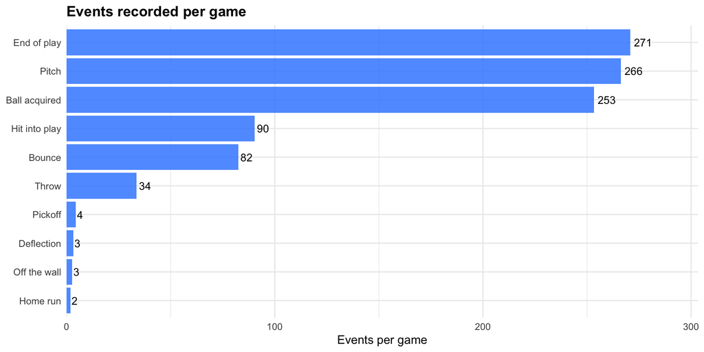

```r
# What kinds of events are recorded, and how often?
sample_games <- head(model_games, 12)

ev_sample <- ball_events %>%
  filter(game_string %in% sample_games) %>%
  collect() %>%
  mutate(across(c(play_per_game, timestamp, player_id, ball_eventcode),
                as.numeric))

ev_labels <- c("1" = "Pitch", "2" = "Ball acquired", "3" = "Throw",
               "4" = "Hit into play", "5" = "End of play", "6" = "Pickoff",
               "9" = "Deflection", "10" = "Off the wall", "11" = "Home run",
               "16" = "Bounce")

ev_sample %>%
  filter(ball_eventcode %in% as.numeric(names(ev_labels))) %>%
  count(ball_eventcode) %>%
  mutate(event = ev_labels[as.character(ball_eventcode)],
         per_game = n / length(sample_games)) %>%
  ggplot(aes(x = reorder(event, per_game), y = per_game)) +
  geom_col(fill = BLUE, alpha = 0.85) +
  geom_text(aes(label = round(per_game)), hjust = -0.2, size = 3.5) +
  coord_flip() +
  scale_y_continuous(expand = expansion(mult = c(0, 0.12))) +
  labs(title = "Events recorded per game",
       x = NULL, y = "Events per game") +
  theme_minimal(base_size = 11) +
  theme(plot.title = element_text(face = "bold"))
```

## Ball tracking

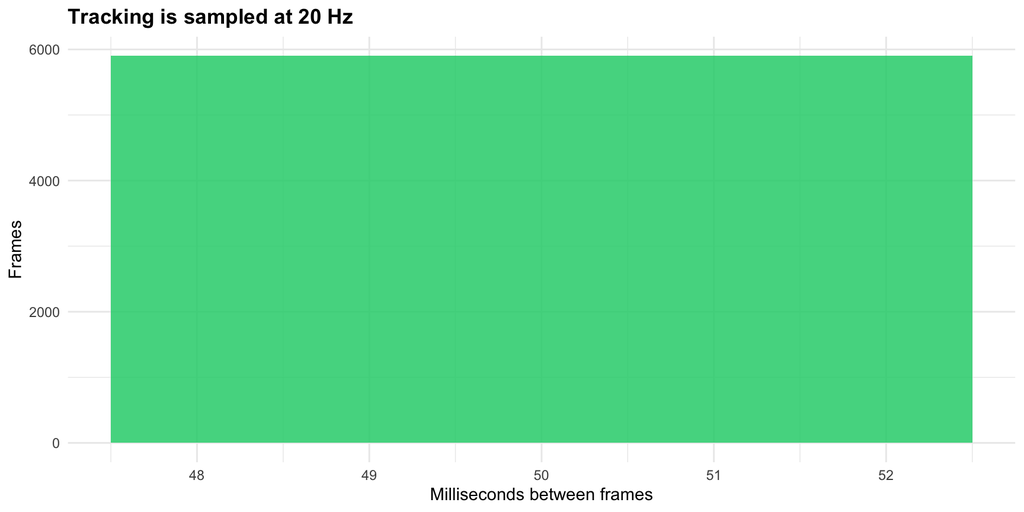

```r
# How many frames does a single play get, and at what rate?
ball_sample <- ball_positions %>%
  filter(game_string == model_games[1]) %>%
  collect() %>%
  mutate(across(everything(), as.numeric))

frame_gaps <- ball_sample %>%
  arrange(play_per_game, timestamp) %>%
  group_by(play_per_game) %>%
  mutate(gap = timestamp - lag(timestamp)) %>%
  ungroup() %>%
  filter(!is.na(gap), gap > 0, gap < 500)

sample_rate <- 1000 / median(frame_gaps$gap)

ggplot(frame_gaps, aes(gap)) +
  geom_histogram(binwidth = 5, fill = GREEN, alpha = 0.85) +
  labs(title = paste0("Tracking is sampled at ", round(sample_rate), " Hz"),
       x = "Milliseconds between frames", y = "Frames") +
  theme_minimal(base_size = 11) +
  theme(plot.title = element_text(face = "bold"))
```

Every 50 ms, so **20 frames per second**. That is the resolution behind every speed, distance and angle in this project — a runner covering 30 ft/s moves 1.5 feet between frames.

## Player tracking coverage

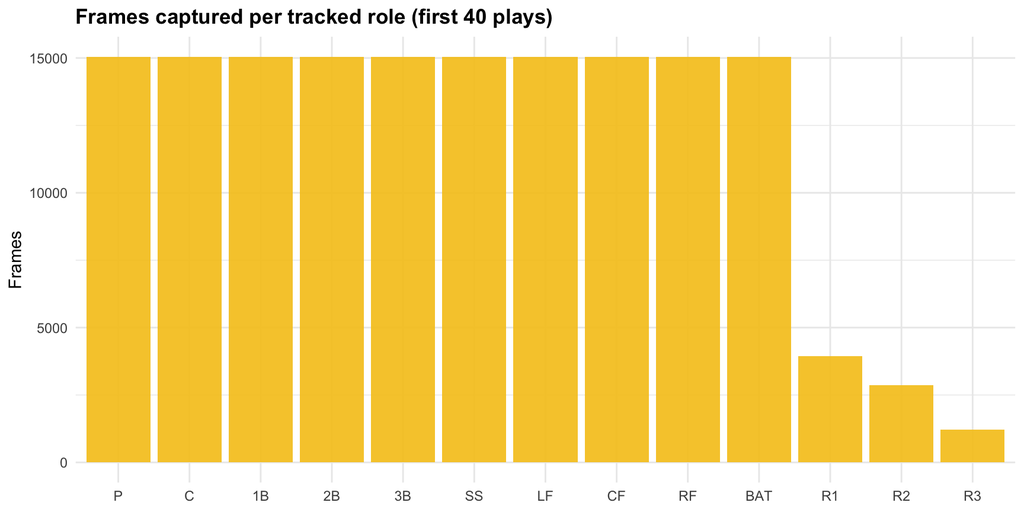

```r
# Which players are tracked, and for how much of a play?
pl_sample <- player_positions %>%
  filter(game_string == model_games[1], play_per_game <= 40) %>%
  collect() %>%
  mutate(across(everything(), as.numeric))

pl_sample %>%
  filter(player_id <= 13) %>%
  count(player_id) %>%
  mutate(role = POS[as.character(player_id)]) %>%
  ggplot(aes(x = reorder(role, player_id), y = n)) +
  geom_col(fill = GOLD, alpha = 0.9) +
  labs(title = "Frames captured per tracked role (first 40 plays)",
       x = NULL, y = "Frames") +
  theme_minimal(base_size = 11) +
  theme(plot.title = element_text(face = "bold"))
```

All nine fielders plus the batter are tracked on every play. Runners only appear when they are on base, which is exactly the signal used to reconstruct the base state.

# Part 1 — From Tracking to Play-by-Play

## Step 1 — What is missing

**PROBLEM:** The `lineups` table tells us who is on each base, but nothing records **outs**, **the count** or **the score**. Win Probability Added and Leverage Index are functions of

$$(\text{inning},\ \text{half},\ \text{outs},\ \text{base state},\ \text{score differential})$$

so none of them exist until that state is rebuilt. This is the foundation of everything downstream.

```r
# Look at one half-inning: occupancy is there, outs and score are not
lineups %>%
  filter(game_string == model_games[1], inning == 1, half_inning == "Bottom") %>%
  select(at_bat, play_per_game, batter, on_1b, on_2b, on_3b) %>%
  head(8) %>%
  kbl_or_note("Base occupancy is recorded; outs and score are not")
```

Base occupancy is recorded; outs and score are not

| at_bat | play_per_game | batter | on_1b | on_2b | on_3b |
| --- | --- | --- | --- | --- | --- |
| 4 | 9 | PHD-8619 | NA | NA | NA |
| 4 | 10 | PHD-8619 | NA | NA | NA |
| 4 | 11 | PHD-8619 | NA | NA | NA |
| 5 | 12 | PHD-7743 | NA | PHD-8619 | NA |
| 5 | 13 | PHD-7743 | NA | PHD-8619 | NA |
| 5 | 14 | PHD-7743 | NA | PHD-8619 | NA |
| 6 | 15 | PHD-6069 | NA | PHD-8619 | NA |
| 6 | 16 | PHD-6069 | NA | PHD-8619 | NA |

## Step 2 — Deciding what happened in each at-bat

Two independent signals tell us the outcome. **Occupancy** says where the batter ended up: if he appears on second base at the next at-bat, he doubled. **The event stream** says how: whether the ball was actually put in play.

The subtle part is that a foul ball and a live batted ball share event code 4. An at-bat that ends in a walk usually contains a foul somewhere, so checking “was there a code 4” would call that walk a single. Only the **last** play of the at-bat decides the outcome, and a live ball is one that somebody subsequently fields.

```r
# TRUE only if the final play was a batted ball that stayed live
is_live_contact <- function(codes) {
  if (length(codes) == 0)             return(FALSE)
  if (EV[["HOMERUN"]] %in% codes)     return(TRUE)
  if (!(EV[["HIT"]] %in% codes))      return(FALSE)

  # everything recorded after contact -- a foul has nothing after it
  after_hit <- codes[-seq_len(which(codes == EV[["HIT"]])[1])]
  any(after_hit %in% LIVE_CODES)
}

# Quick check on the two cases that matter
foul <- c(EV[["HIT"]], EV[["END"]])                    # contact, then dead
live <- c(EV[["HIT"]], EV[["BOUNCE"]], EV[["ACQUIRED"]])  # contact, then fielded

c(foul = is_live_contact(foul), live = is_live_contact(live))
```

```
 foul  live
FALSE  TRUE
```

## Step 3 — Balancing the half-inning

**METHOD:** For each half-inning, walk the at-bats and apply an accounting identity. Everyone on base before the play, plus the batter, has to finish in exactly one of three places — still on base, across the plate, or retired:

$$|B| + 1 = |A| + \text{runs} + \text{outs}$$

$|B|$ and $|A|$ come from the lineup table. The half-inning must total three outs, which closes the system.

Two traps, both of which I hit:

1. **The last at-bat of a half-inning has no observed “after” state.** Runners left on base then look identical to runs. Applying the identity there scored every stranded runner, so it is skipped and the remaining outs are assigned.
2. **Substitutions look like runs.** A pinch-runner replaces a player code, and the original vanishes. Baseball physics bounds this: a runner on first cannot score on an infield out.

```r
# Ceiling on how many runners can score, given what the batter did
max_runs_possible <- function(outcome, on1, on2, on3) {
  n1 <- as.integer(!is.na(on1))
  n2 <- as.integer(!is.na(on2))
  n3 <- as.integer(!is.na(on3))

  switch(outcome,
         "home_run" = n1 + n2 + n3 + 1L,   # everyone scores
         "triple"   = n1 + n2 + n3,
         "double"   = n1 + n2 + n3,        # first can score on one in the gap
         "single"   = n2 + n3,             # first almost never scores
         "walk_hbp" = if (n1 && n2 && n3) 1L else 0L,   # forced run only
         "out"      = n3,                  # sac fly or run-scoring groundout
         n1 + n2 + n3)
}

# Bases empty, batter out -- nobody can score
max_runs_possible("out", NA, NA, NA)
```

```
[1] 0
```

## Step 4 — Running the reconstruction

```r
# Encode base occupancy as 0-7
base_code <- function(on1, on2, on3) {
  as.integer(!is.na(on1)) + 2L * as.integer(!is.na(on2)) + 4L * as.integer(!is.na(on3))
}

# Readable version of the situation, for the scoreboard copy
describe_state <- function(code, outs) {
  on1 <- bitwAnd(code, 1L) > 0
  on2 <- bitwAnd(code, 2L) > 0
  on3 <- bitwAnd(code, 4L) > 0

  bases <- case_when(
    !on1 & !on2 & !on3 ~ "bases empty",
    on1 & on2 & on3    ~ "bases loaded",
    on1 & on3          ~ "runners on the corners",
    on1 & on2          ~ "runners on first and second",
    on2 & on3          ~ "runners on second and third",
    on1                ~ "a runner on first",
    on2                ~ "a runner on second",
    TRUE               ~ "a runner on third")

  paste0(bases, ", ", case_when(outs == 0 ~ "nobody out",
                                outs == 1 ~ "one out",
                                TRUE      ~ "two outs"))
}
```

```r
# Rebuild one game into a play-by-play table
build_play_by_play <- function(gs) {

  lu <- lineups %>% filter(game_string == gs)
  if (nrow(lu) == 0) return(NULL)

  ev <- ball_events %>%
    filter(game_string == gs) %>%
    collect() %>%
    mutate(across(c(play_per_game, timestamp, player_id, ball_eventcode),
                  as.numeric))

  # A pickoff is not a plate appearance
  pa <- lu %>% filter(!coalesce(is_pickoff, FALSE))

  # One row per at-bat; the state is read at its first pitch
  ab <- pa %>%
    group_by(inning, half_inning, at_bat) %>%
    summarise(first_play = min(play_per_game), last_play = max(play_per_game),
              pitches = n(), batter = first(batter), pitcher = first(pitcher),
              on_1b = first(on_1b), on_2b = first(on_2b), on_3b = first(on_3b),
              home_team = first(home_team), away_team = first(away_team),
              .groups = "drop") %>%
    mutate(half_order = as.integer(half_inning == "Bottom")) %>%
    arrange(inning, half_order, at_bat)

  out <- list()

  # Work half-inning by half-inning, because the 3-out rule is what closes the system
  for (key in unique(paste(ab$inning, ab$half_order))) {

    grp <- ab %>% filter(paste(inning, half_order) == key) %>% arrange(at_bat)
    n   <- nrow(grp)
    rec <- vector("list", n)

    for (i in seq_len(n)) {
      r   <- grp[i, ]
      nxt <- if (i < n) grp[i + 1, ] else NULL

      before <- c(r$on_1b, r$on_2b, r$on_3b); before <- before[!is.na(before)]
      after  <- if (is.null(nxt)) character(0) else {
        a <- c(nxt$on_1b, nxt$on_2b, nxt$on_3b); a[!is.na(a)]
      }

      # Which base does the batter occupy next time we see the field?
      dest <- NA_integer_
      if (!is.null(nxt)) {
        dest <- 0L
        if      (!is.na(nxt$on_1b) && nxt$on_1b == r$batter) dest <- 1L
        else if (!is.na(nxt$on_2b) && nxt$on_2b == r$batter) dest <- 2L
        else if (!is.na(nxt$on_3b) && nxt$on_3b == r$batter) dest <- 3L
      }

      # Only the final play of the at-bat decides the outcome
      codes <- ev %>%
        filter(play_per_game == r$last_play) %>%
        arrange(timestamp) %>%
        pull(ball_eventcode)

      live <- is_live_contact(codes)

      outcome <- if (EV[["HOMERUN"]] %in% codes) {
        "home_run"
      } else if (!is.na(dest) && dest > 0) {
        if (!live) "walk_hbp"
        else switch(as.character(dest), "1" = "single", "2" = "double",
                    "3" = "triple", "single")
      } else "out"

      # Departures: skipped on the last at-bat, where stranded runners would
      # be indistinguishable from runs
      last_ab     <- is.null(nxt)
      departed    <- if (last_ab) 0L else max(0L, length(before) + 1L - length(after))
      batter_out  <- if (is.na(dest) || dest == 0) 1L else 0L
      runners_out <- max(0L, departed - batter_out)

      rec[[i]] <- list(
        inning = as.integer(r$inning), half_inning = as.character(r$half_inning),
        at_bat = as.integer(r$at_bat), first_play = as.numeric(r$first_play),
        last_play = as.numeric(r$last_play), pitches = as.integer(r$pitches),
        batter = as.character(r$batter), pitcher = as.character(r$pitcher),
        home_team = as.character(r$home_team), away_team = as.character(r$away_team),
        on_1b = as.character(r$on_1b), on_2b = as.character(r$on_2b),
        on_3b = as.character(r$on_3b),
        outcome = outcome, ball_in_play = live, n_before = length(before),
        batter_out = batter_out, runners_gone = runners_out, last_ab = last_ab)
    }

    # Any outs the batters do not account for must be runners retired on the bases
    batter_outs <- vapply(rec, function(x) x$batter_out, integer(1))
    needed  <- min(max(0L, OUTS_PER_HALF - sum(batter_outs)),
                   sum(vapply(rec, function(x) x$runners_gone, integer(1))))

    # Charge those first where the batter was also retired -- the double play
    ord <- order(batter_outs == 0,
                 !vapply(rec, function(x) x$ball_in_play, logical(1)))
    runner_outs <- integer(n)
    left <- needed
    for (i in ord) {
      if (left <= 0) break
      if (rec[[i]]$outcome == "home_run") next
      take <- min(rec[[i]]$runners_gone, left)
      runner_outs[i] <- take
      left <- left - take
    }

    for (i in seq_len(n)) {
      if (rec[[i]]$outcome == "home_run") {
        rec[[i]]$runs <- rec[[i]]$n_before + 1L
        rec[[i]]$outs_on_play <- 0L
      } else if (rec[[i]]$last_ab) {
        used <- sum(vapply(rec[seq_len(i - 1)], function(x) x$outs_on_play, integer(1)))
        rec[[i]]$outs_on_play <- max(0L, OUTS_PER_HALF - used)
        rec[[i]]$runs <- 0L
      } else {
        rec[[i]]$outs_on_play <- batter_outs[i] + runner_outs[i]
        cap <- max_runs_possible(rec[[i]]$outcome, rec[[i]]$on_1b,
                                 rec[[i]]$on_2b, rec[[i]]$on_3b)
        rec[[i]]$runs <- as.integer(min(max(0L, rec[[i]]$runners_gone - runner_outs[i]),
                                        cap))
      }
    }

    # Running out count, clamped so the state can never be illegal
    outs_before <- 0L
    for (i in seq_len(n)) {
      room <- OUTS_PER_HALF - outs_before
      rec[[i]]$outs_on_play <- max(0L, min(rec[[i]]$outs_on_play, room))
      rec[[i]]$outs_before  <- min(outs_before, OUTS_PER_HALF - 1L)
      rec[[i]]$base_state   <- base_code(rec[[i]]$on_1b, rec[[i]]$on_2b, rec[[i]]$on_3b)
      outs_before <- min(OUTS_PER_HALF, outs_before + rec[[i]]$outs_on_play)
    }

    out <- c(out, rec)
  }

  df <- bind_rows(lapply(out, function(x) {
    x$last_ab <- NULL; x$batter_out <- NULL; x$runners_gone <- NULL
    as_tibble(x)
  }))

  # Score progression and the situation string
  df <- df %>%
    arrange(inning, as.integer(half_inning == "Bottom"), at_bat) %>%
    mutate(
      game_string = gs,
      batting_team = if_else(half_inning == "Top", away_team, home_team),
      home_score = cumsum(if_else(half_inning == "Bottom", runs, 0L)),
      away_score = cumsum(if_else(half_inning == "Top", runs, 0L)),
      home_before = home_score - if_else(half_inning == "Bottom", runs, 0L),
      away_before = away_score - if_else(half_inning == "Top", runs, 0L),
      score_diff = if_else(half_inning == "Top",
                           away_before - home_before, home_before - away_before),
      situation = paste0(if_else(half_inning == "Top", "Top ", "Bot "), inning,
                         ", ", describe_state(base_state, outs_before)))

  # The win-probability target has to be complementary. Writing it as two
  # strict inequalities marks BOTH sides as losers when a game ties, and the
  # model then trains on contradictory rows. Ties go to the away side.
  hf <- max(df$home_score); af <- max(df$away_score)

  df %>% mutate(home_final = hf, away_final = af,
                batting_won = if_else(half_inning == "Bottom",
                                      as.integer(hf > af), as.integer(af >= hf)))
}
```

```r
# Rebuild every game in the folder. Independent per game, so it is spread
# across cores; mclapply falls back to one core on Windows.
n_cores <- if (.Platform$OS.type == "unix") max(1L, parallel::detectCores() - 1L) else 1L

pbp <- cached(paste0("play_by_play_", length(model_games)), {
  parallel::mclapply(model_games, function(g) {
    tryCatch(build_play_by_play(g), error = function(e) NULL)
  }, mc.cores = n_cores) %>% bind_rows()
})

n_games <- n_distinct(pbp$game_string)
```

```r
# Does the reconstruction look like baseball?
tibble(
  metric = c("Runs per game", "Hits per game", "Walks/HBP per game",
             "Home runs per game", "Plate appearances per game"),
  reconstructed = round(c(
    sum(pbp$runs) / n_games,
    sum(pbp$outcome %in% c("single", "double", "triple", "home_run")) / n_games,
    sum(pbp$outcome == "walk_hbp") / n_games,
    sum(pbp$outcome == "home_run") / n_games,
    nrow(pbp) / n_games), 2),
  real_milb = c(9.5, 18.0, 7.0, 2.0, 76.0)
) %>%
  kbl_or_note(paste0("Reconstruction vs real Minor League rates (",
                       n_games, " games, ", comma(nrow(pbp)), " plate appearances)"))
```

Reconstruction vs real Minor League rates (25 games, 1,756 plate appearances)

| metric | reconstructed | real_milb |
| --- | --- | --- |
| Runs per game | 8.32 | 9.5 |
| Hits per game | 16.80 | 18.0 |
| Walks/HBP per game | 8.04 | 7.0 |
| Home runs per game | 1.96 | 2.0 |
| Plate appearances per game | 70.24 | 76.0 |

# Part 2 — Win Probability, WPA and Leverage

#### Methodology

Run expectancy is estimated empirically: for every base-out state, the average number of runs scored from there to the end of the half-inning. Win probability is then a logistic model,

$$\text{logit }P(\text{batting team wins}) = \beta_0 + \beta_1 D + \beta_2 I +
\beta_3 (D \times I) + \beta_4 \frac{D}{I+1} + \beta_5 O + \beta_6 RE + \beta_7 H$$

where $D$ is the score differential, $I$ the innings remaining, $O$ the outs, $RE$ the run expectancy of the current base-out state and $H$ an indicator for the home half. The $D \times I$ interaction is the important one — it lets a one-run lead be worth far more in the ninth than in the first.

A model is used rather than an empirical lookup because 250 games cannot fill an (inning × base-out × margin) grid. A lookup gives jagged, non-monotonic probabilities that look broken on a scoreboard.

## Step 5 — Run expectancy

```r
# Runs from each state to the end of the half-inning
re_table <- pbp %>%
  arrange(game_string, inning, half_inning, at_bat) %>%
  group_by(game_string, inning, half_inning) %>%
  mutate(runs_to_end = rev(cumsum(rev(runs)))) %>%
  ungroup() %>%
  filter(outs_before < OUTS_PER_HALF) %>%
  group_by(base_state, outs_before) %>%
  summarise(run_expectancy = mean(runs_to_end), n = n(), .groups = "drop")

# Fast lookup used by the model features
re_lookup <- setNames(re_table$run_expectancy,
                      paste(re_table$base_state, re_table$outs_before))

re_of <- function(state, outs) {
  v <- unname(re_lookup[paste(state, outs)])
  v[is.na(v) | outs >= OUTS_PER_HALF] <- 0
  v
}

re_table %>%
  mutate(bases = BASE_LABELS[base_state + 1],
         outs = paste0(outs_before, if_else(outs_before == 1L, " out", " outs"))) %>%
  select(bases, outs, run_expectancy) %>%
  pivot_wider(names_from = outs, values_from = run_expectancy) %>%
  mutate(across(where(is.numeric), ~ round(.x, 3))) %>%
  kbl_or_note("Run expectancy — runs scored from each state to the end of the inning")
```

Run expectancy — runs scored from each state to the end of the inning

| bases | 0 outs | 1 out | 2 outs |
| --- | --- | --- | --- |
| ___ | 0.502 | 0.315 | 0.142 |
| 1__ | 0.740 | 0.496 | 0.263 |
| _2_ | 1.083 | 0.744 | 0.328 |
| 12_ | 1.324 | 0.971 | 0.406 |
| __3 | 1.750 | 0.923 | 0.571 |
| 1_3 | 1.600 | 1.400 | 0.481 |
| _23 | 1.600 | 1.833 | 1.000 |
| 123 | 1.750 | 1.136 | 0.640 |

## Step 6 — The win probability model

```r
# Model features, built from the reconstructed state
wp_features <- function(d) {
  d %>% mutate(
    innings_left = pmax(0, 9 - inning + if_else(half_inning == "Top", 0.5, 0)),
    is_home_half = as.integer(half_inning == "Bottom"),
    runners_on   = as.integer(bitwAnd(base_state, 1L) > 0) +
                   as.integer(bitwAnd(base_state, 2L) > 0) +
                   as.integer(bitwAnd(base_state, 4L) > 0),
    risp         = as.integer(bitwAnd(base_state, 6L) > 0),
    re_state     = re_of(base_state, outs_before),
    diff_x_left  = score_diff * innings_left,
    diff_per_left = score_diff / (innings_left + 1),
    outs         = outs_before)
}

wp_model <- glm(batting_won ~ score_diff + innings_left + diff_x_left +
                  diff_per_left + outs + re_state + is_home_half +
                  runners_on + risp,
                family = binomial(), data = wp_features(pbp))

predict_wp <- function(d) as.numeric(predict(wp_model, wp_features(d),
                                             type = "response"))

# Fit quality
wp_p <- predict_wp(pbp)
wp_y <- pbp$batting_won

wp_acc   <- round(mean((wp_p >= 0.5) == (wp_y == 1)), 3)
wp_brier <- round(mean((wp_p - wp_y)^2), 3)

tibble(metric = c("Plate appearances", "Accuracy", "Brier score", "Base rate"),
       value  = c(comma(nrow(pbp)), wp_acc, wp_brier, round(mean(wp_y), 3))) %>%
  kbl_or_note("Win probability model fit")
```

Win probability model fit

| metric | value |
| --- | --- |
| Plate appearances | 1,756 |
| Accuracy | 0.688 |
| Brier score | 0.187 |
| Base rate | 0.513 |

## Step 7 — Win Probability Added

WPA is simply the change in win probability across a plate appearance. The one subtlety is the half-inning flip: after the third out the other team bats, so the batting team’s win probability becomes the **complement** of the next state’s.

```r
pbp <- pbp %>% arrange(game_string, inning,
                       as.integer(half_inning == "Bottom"), at_bat)
pbp$wp_before <- predict_wp(pbp)

pbp <- pbp %>%
  group_by(game_string) %>%
  mutate(
    next_wp   = lead(wp_before),
    same_side = lead(half_inning) == half_inning & lead(inning) == inning,
    wp_after  = case_when(is.na(next_wp) ~ as.numeric(batting_won),
                          same_side      ~ next_wp,
                          TRUE           ~ 1 - next_wp),
    wpa = wp_after - wp_before) %>%
  select(-next_wp, -same_side) %>%
  ungroup()
```

## Step 8 — Leverage Index

**METHOD:** Leverage asks *how much can the game move from here?* For each state we enumerate the plausible outcomes of a plate appearance with their league frequencies, apply each one, and average the resulting $|\Delta WP|$:

$$LI(\text{state}) = \frac{E\big[\,|\Delta WP|\ \big|\ \text{state}\big]}{E\big[\,|\Delta WP|\,\big]}$$

The denominator normalises so an average plate appearance is exactly 1.0.

```r
# What a state becomes after each outcome -- applied to every row at once
apply_outcome <- function(state, outs, kind) {
  n   <- length(state)
  on1 <- bitwAnd(state, 1L) > 0
  on2 <- bitwAnd(state, 2L) > 0
  on3 <- bitwAnd(state, 4L) > 0
  bits <- function(a, b, c) as.integer(a) + 2L * as.integer(b) + 4L * as.integer(c)

  switch(kind,
    "out"      = list(base = state, outs = outs + 1L, runs = rep(0L, n)),
    "walk_hbp" = list(base = case_when(!on1 ~ bits(TRUE, on2, on3),
                                       !on2 ~ bits(TRUE, TRUE, on3),
                                       TRUE ~ 7L),
                      outs = outs, runs = as.integer(on1 & on2 & on3)),
    "single"   = list(base = bits(TRUE, on1, rep(FALSE, n)), outs = outs,
                      runs = as.integer(on2) + as.integer(on3)),
    "double"   = list(base = rep(2L, n), outs = outs,
                      runs = as.integer(on1) + as.integer(on2) + as.integer(on3)),
    "triple"   = list(base = rep(4L, n), outs = outs,
                      runs = as.integer(on1) + as.integer(on2) + as.integer(on3)),
    "home_run" = list(base = rep(0L, n), outs = outs,
                      runs = 1L + as.integer(on1) + as.integer(on2) + as.integer(on3)),
    list(base = state, outs = outs, runs = rep(0L, n)))
}
```

```r
# League frequency of each outcome
mix <- pbp %>% count(outcome) %>% mutate(p = n / sum(n))

wp_now <- predict_wp(pbp)
swing  <- rep(0, nrow(pbp))

# One prediction per outcome across the whole season, not one per plate
# appearance -- six model calls instead of tens of thousands
for (k in mix$outcome) {

  st    <- apply_outcome(pbp$base_state, pbp$outs_before, k)
  ended <- st$outs >= OUTS_PER_HALF

  nxt <- tibble(
    inning      = if_else(ended & pbp$half_inning == "Bottom", pbp$inning + 1L, pbp$inning),
    half_inning = if_else(ended, if_else(pbp$half_inning == "Top", "Bottom", "Top"),
                          pbp$half_inning),
    outs_before = if_else(ended, 0L, st$outs),
    base_state  = if_else(ended, 0L, st$base),
    score_diff  = if_else(ended, -(pbp$score_diff + st$runs), pbp$score_diff + st$runs))

  wp_next <- predict_wp(nxt)
  wp_next <- if_else(ended, 1 - wp_next, wp_next)   # sides changed

  swing <- swing + mix$p[mix$outcome == k] * abs(wp_next - wp_now)
}

pbp <- pbp %>%
  mutate(leverage = swing / mean(swing, na.rm = TRUE),
         # win impact weighted by what was at stake, compressed so one enormous
         # play does not flatten the leaderboard
         clutch = 100 * tanh(3 * abs(wpa) * sqrt(pmax(leverage, 0))))

li_mean <- round(mean(pbp$leverage), 3)
li_max  <- round(max(pbp$leverage), 2)
```

```r
# The biggest swings of the season
pbp %>%
  arrange(desc(abs(wpa))) %>%
  transmute(game = game_string, inning, half = half_inning, batter, outcome, runs,
            wp_before = round(wp_before, 3), wp_after = round(wp_after, 3),
            WPA = round(wpa, 3), leverage = round(leverage, 2)) %>%
  head(8) %>%
  kbl_or_note("Biggest win-probability swings of the season")
```

Biggest win-probability swings of the season

| game | inning | half | batter | outcome | runs | wp_before | wp_after | WPA | leverage |
| --- | --- | --- | --- | --- | --- | --- | --- | --- | --- |
| y1_d083_NXS_ARN | 10 | Bottom | ARN-1503 | home_run | 2 | 0.261 | 1.000 | 0.739 | 2.07 |
| y1_d072_URD_ARN | 10 | Bottom | ARN-2183 | out | 0 | 0.627 | 0.000 | -0.627 | 5.54 |
| y1_d066_VAS_PHD | 8 | Bottom | PHD-9663 | out | 0 | 0.552 | 0.000 | -0.552 | 2.20 |
| y1_d077.5_PHD_VAS | 7 | Top | PHD-8619 | out | 0 | 0.499 | 1.000 | 0.501 | 2.53 |
| y1_d068_SQF_ARN | 10 | Top | SQF-1665 | out | 0 | 0.504 | 1.000 | 0.496 | 0.93 |
| y1_d074_AIP_ARN | 7 | Bottom | ARN-9340 | out | 0 | 0.384 | 0.000 | -0.384 | 4.86 |
| y1_d068_SQF_ARN | 7 | Top | SQF-3636 | home_run | 3 | 0.181 | 0.495 | 0.314 | 2.93 |
| y1_d077.5_PHD_VAS | 6 | Bottom | VAS-4154 | double | 2 | 0.308 | 0.602 | 0.294 | 6.19 |

**RESULT:**

Win probability fits at **0.688** accuracy with a Brier score of **0.187**. Leverage normalises to a mean of **1** with a maximum of **7.57**. The largest swings are walk-off home runs and game-ending outs — the model was never told what a walk-off is, it simply found the plays where win probability moved most.

# Part 3 — Tracking Metrics

## Step 9 — One extraction pass

Every metric below comes from the same pass over the tracking data. Doing it once per game and caching keeps the document re-renderable in seconds.

```r
# Speed between consecutive frames, in ft/s
frame_speed <- function(x, y, ts) {
  dt <- diff(ts) / 1000
  d  <- sqrt(diff(x)^2 + diff(y)^2)
  ifelse(dt > 0, d / dt, NA_real_)
}

# A high percentile rather than the maximum -- one mistracked frame can
# produce an absurd instantaneous value
peak <- function(v, p = 0.90) {
  v <- v[is.finite(v)]
  if (length(v) == 0) return(NA_real_)
  unname(quantile(v, p))
}

# 3-D ball speed between frames
ball_speed <- function(b) {
  dt <- diff(b$timestamp) / 1000
  d  <- sqrt(diff(b$ball_position_x)^2 + diff(b$ball_position_y)^2 +
             diff(b$ball_position_z)^2)
  ifelse(dt > 0, d / dt, NA_real_)
}

dist_to <- function(x, y, pt) sqrt((x - pt[1])^2 + (y - pt[2])^2)
```

```r
# Empty prototypes, one per table.
#
# bind_rows() on an empty list returns a 0x0 tibble with NO columns, so any
# later summarise() fails with "object 'exchange' not found" rather than simply
# producing an empty result. On a small sample plenty of these tables legitimately
# have no rows -- a single game may contain no throw to second, no double play
# turn, no pickoff -- so every table falls back to a typed empty tibble.
PROTO <- list(
  pitches = tibble(game_string = character(), play = numeric(),
                   pitch_velo = numeric(), plate_x = numeric(),
                   plate_z = numeric(), extension = numeric(),
                   induced_break = numeric(), horizontal_break = numeric(),
                   in_play = integer()),
  hits    = tibble(game_string = character(), play = numeric(),
                   exit_velo = numeric(), launch = numeric(), carry = numeric(),
                   spray_x = numeric(), spray_y = numeric(), is_hr = integer()),
  catches = tibble(game_string = character(), play = numeric(),
                   fielder_id = numeric(), catch_made = integer(),
                   route = numeric(), hang = numeric(), closing = numeric(),
                   efficiency = numeric()),
  throws  = tibble(game_string = character(), play = numeric(),
                   fielder_id = numeric(), throw_velo = numeric(),
                   transfer = numeric()),
  runs    = tibble(game_string = character(), play = numeric(),
                   sprint_mph = numeric(), time_to_first = numeric(),
                   burst = numeric(), path_efficiency = numeric()),
  pivots  = tibble(game_string = character(), play = numeric(),
                   pos = character(), pivot = numeric()),
  pops    = tibble(game_string = character(), play = numeric(),
                   exchange = numeric(), throw_velo = numeric()),
  leads   = tibble(game_string = character(), play = numeric(),
                   runner = character(), lead_ft = numeric(),
                   burst_mph = numeric()))

# Bind a list of rows, falling back to the typed prototype when there are none
bind_or_empty <- function(rows, proto) {
  out <- bind_rows(rows)
  if (nrow(out) == 0) proto else out
}

# Pull every tracking measurement we need for one game
extract_game <- function(gs) {

  ev <- ball_events %>% filter(game_string == gs) %>% collect() %>%
    mutate(across(c(play_per_game, timestamp, player_id, ball_eventcode), as.numeric))
  bp <- ball_positions %>% filter(game_string == gs) %>% collect() %>%
    mutate(across(c(play_per_game, timestamp, ball_position_x,
                    ball_position_y, ball_position_z), as.numeric))
  pp <- player_positions %>% filter(game_string == gs) %>% collect() %>%
    mutate(across(c(play_per_game, timestamp, player_id, field_x, field_y), as.numeric)) %>%
    filter(player_id <= 13)

  pitches <- list(); hits <- list(); catches <- list()
  throws  <- list(); runs_l <- list(); pivots <- list(); pops <- list()
  leads   <- list()

  for (pl in sort(unique(ev$play_per_game))) {

    e <- ev %>% filter(play_per_game == pl) %>% arrange(timestamp)
    b <- bp %>% filter(play_per_game == pl) %>% arrange(timestamp)
    if (nrow(b) < 3) next

    ## ---- the pitch -------------------------------------------------------
    t_pitch <- e$timestamp[e$ball_eventcode == EV[["PITCH"]]]
    if (length(t_pitch)) {
      t0 <- min(t_pitch)
      w  <- b %>% filter(timestamp >= t0, timestamp <= t0 + 800)
      if (nrow(w) >= 3) {
        v <- peak(ball_speed(w), 0.90) * MPH

        # Where the pitch crossed the plate: interpolate between the frames
        # that straddle y = 0
        yv <- w$ball_position_y
        cross <- which(yv[-length(yv)] > 0 & yv[-1] <= 0)[1]
        px <- NA_real_; pz <- NA_real_; ext <- NA_real_
        if (!is.na(cross)) {
          f  <- yv[cross] / (yv[cross] - yv[cross + 1])
          px <- w$ball_position_x[cross] + f * diff(w$ball_position_x[cross:(cross+1)])
          pz <- w$ball_position_z[cross] + f * diff(w$ball_position_z[cross:(cross+1)])
        }
        # Extension: how far down the mound the ball was released
        ext <- RUBBER_FT - max(yv)

        # Movement. Gravity alone drops a 90 mph pitch about 39 inches, so the
        # raw deviation from a straight line makes every pitch look filthy.
        # Subtracting it leaves the induced (spin) component.
        flight <- if (is.finite(v) && v > 0) max(yv) / ((v / MPH) * DRAG_FACTOR) else NA_real_
        drop_g <- if (is.finite(flight)) 0.5 * GRAVITY * flight^2 * 12 else NA_real_

        ivb <- NA_real_; hb <- NA_real_
        if (nrow(w) >= 4 && is.finite(drop_g)) {
          # straight line from release along the initial direction
          slope_z <- (w$ball_position_z[2] - w$ball_position_z[1]) /
                     (w$ball_position_y[2] - w$ball_position_y[1])
          slope_x <- (w$ball_position_x[2] - w$ball_position_x[1]) /
                     (w$ball_position_y[2] - w$ball_position_y[1])
          dy <- 0 - w$ball_position_y[1]
          ivb <- ((pz - (w$ball_position_z[1] + slope_z * dy)) * 12) + drop_g
          hb  <-  (px - (w$ball_position_x[1] + slope_x * dy)) * 12
        }

        if (is.finite(v) && v > 40 && v <= 103) {
          pitches[[length(pitches) + 1]] <- tibble(
            game_string = gs, play = pl, pitch_velo = round(v, 1),
            plate_x = round(px, 3), plate_z = round(pz, 3),
            extension = round(ext, 2),
            induced_break = round(ivb, 1), horizontal_break = round(hb, 1),
            in_play = as.integer(EV[["HIT"]] %in% e$ball_eventcode))
        }
      }
    }

    ## ---- the batted ball -------------------------------------------------
    t_hit <- e$timestamp[e$ball_eventcode == EV[["HIT"]]]
    if (!length(t_hit)) next
    th <- min(t_hit)

    w <- b %>% filter(timestamp >= th, timestamp <= th + 400)
    if (nrow(w) >= 3) {
      exit_v <- peak(ball_speed(w), 0.95) * MPH

      # Launch angle from the first ~150 ms of flight
      k <- min(4, nrow(w) - 1)
      horiz <- sqrt((w$ball_position_x[k+1] - w$ball_position_x[1])^2 +
                    (w$ball_position_y[k+1] - w$ball_position_y[1])^2)
      la <- if (horiz > 0) {
        atan2(w$ball_position_z[k+1] - w$ball_position_z[1], horiz) * 180 / pi
      } else NA_real_
```

```r
      # Carry: distance at the first bounce, NOT the ball's furthest point --
      # relay throws move it further from home after it lands
      bpost  <- b %>% filter(timestamp >= th)
      bounce <- e$timestamp[e$ball_eventcode == EV[["BOUNCE"]] & e$timestamp > th]
      idx <- if (length(bounce)) {
        which.min(abs(bpost$timestamp - min(bounce)))
      } else {
        apex <- which.max(bpost$ball_position_z)
        apex + which.min(abs(bpost$ball_position_z[apex:nrow(bpost)] -
                             bpost$ball_position_z[1])) - 1
      }
      idx <- min(max(idx, 1), nrow(bpost))
      carry <- sqrt(bpost$ball_position_x[idx]^2 + bpost$ball_position_y[idx]^2)

      if (is.finite(exit_v) && exit_v > 20 && exit_v < 125) {
        hits[[length(hits) + 1]] <- tibble(
          game_string = gs, play = pl,
          exit_velo = round(exit_v, 1), launch = round(la, 1),
          carry = round(carry, 1), spray_x = round(bpost$ball_position_x[idx], 1),
          spray_y = round(bpost$ball_position_y[idx], 1),
          is_hr = as.integer(EV[["HOMERUN"]] %in% e$ball_eventcode))
      }
    }

    ## ---- the fielder -----------------------------------------------------
    acq <- e %>% filter(ball_eventcode %in% c(EV[["ACQUIRED"]], EV[["ACQUIRED_UNK"]]),
                        timestamp >= th, player_id >= 1, player_id <= 9)

    ball_depth <- max(sqrt(b$ball_position_x^2 + b$ball_position_y^2))

    if (nrow(acq) && (min(acq$timestamp) - th) / 1000 < 12) {

      fid <- acq$player_id[1]; ta <- acq$timestamp[1]
      trk <- pp %>% filter(player_id == fid) %>% arrange(timestamp)
      p0  <- trk %>% filter(timestamp <= th) %>% tail(1)
      p1  <- trk %>% filter(timestamp <= ta) %>% tail(1)

      if (nrow(p0) && nrow(p1)) {
        route <- sqrt((p1$field_x - p0$field_x)^2 + (p1$field_y - p0$field_y)^2)
        hang  <- (ta - th) / 1000
        run   <- trk %>% filter(timestamp >= th, timestamp <= ta)
        close <- if (nrow(run) >= 3) peak(frame_speed(run$field_x, run$field_y,
                                                      run$timestamp), 0.90) else NA_real_
        # path efficiency: straight line divided by distance actually covered
        travelled <- if (nrow(run) >= 2) {
          sum(sqrt(diff(run$field_x)^2 + diff(run$field_y)^2))
        } else NA_real_

        # A catch opportunity is a ball that reached the outfield
        if (ball_depth > 130 && hang > 0.4 && hang < 8 && route < 160) {
          catches[[length(catches) + 1]] <- tibble(
            game_string = gs, play = pl, fielder_id = fid,
            catch_made = 1L, route = round(route, 1), hang = round(hang, 2),
            closing = round(close, 1),
            efficiency = round(pmin(1, route / pmax(travelled, 1e-6)), 3))
        }
      }

      # Throw velocity after the fielder releases it
      thr <- e %>% filter(ball_eventcode %in% c(EV[["THROW"]], EV[["THROW_UNK"]]),
                          player_id == fid, timestamp >= ta)
      if (nrow(thr)) {
        tt <- thr$timestamp[1]
        wt <- b %>% filter(timestamp >= tt, timestamp <= tt + 500)
        if (nrow(wt) >= 3) {
          tv <- peak(ball_speed(wt), 0.90) * MPH
          if (is.finite(tv) && tv > 30 && tv < 110) {
            throws[[length(throws) + 1]] <- tibble(
              game_string = gs, play = pl, fielder_id = fid,
              throw_velo = round(tv, 1),
              transfer = round((tt - ta) / 1000, 2))
          }
        }
      }
    } else if (ball_depth > 130) {
      # Nobody caught it: find the ball's landing spot and the nearest outfielder
      bpost <- b %>% filter(timestamp >= th)
      land  <- bpost[which.min(bpost$ball_position_z), ]
      hang  <- (land$timestamp - th) / 1000

      best <- NULL
      for (oid in 7:9) {
        o <- pp %>% filter(player_id == oid, timestamp <= th) %>% tail(1)
        if (!nrow(o)) next
        d <- sqrt((o$field_x - land$ball_position_x)^2 +
                  (o$field_y - land$ball_position_y)^2)
        if (is.null(best) || d < best$d) best <- list(id = oid, d = d)
      }
      if (!is.null(best) && hang > 0.4 && hang < 8 && best$d < 200) {
        catches[[length(catches) + 1]] <- tibble(
          game_string = gs, play = pl, fielder_id = best$id,
          catch_made = 0L, route = round(best$d, 1), hang = round(hang, 2),
          closing = NA_real_, efficiency = NA_real_)
      }
    }

    ## ---- the batter's run -------------------------------------------------
    bat <- pp %>% filter(player_id == 10, timestamp >= th) %>% arrange(timestamp)
    if (nrow(bat) >= 5) {
      sp  <- frame_speed(bat$field_x, bat$field_y, bat$timestamp)
      top <- peak(sp, 0.95)

      # Time to first: the frame the runner enters a 4 ft radius of the bag
      d_first <- dist_to(bat$field_x, bat$field_y, BASES$first)
      reach   <- which(d_first <= 4)[1]
      t_first <- if (!is.na(reach)) (bat$timestamp[reach] - th) / 1000 else NA_real_

      # Burst: speed gained over the first 1.5 seconds out of the box
      early <- bat %>% filter(timestamp <= th + 1500)
      burst <- if (nrow(early) >= 3) {
        es <- frame_speed(early$field_x, early$field_y, early$timestamp)
        es <- es[is.finite(es)]
        if (length(es) >= 2) (max(es) - es[1]) / 1.5 else NA_real_
      } else NA_real_

      moved <- sum(sqrt(diff(bat$field_x)^2 + diff(bat$field_y)^2))

      if (is.finite(top) && top > 5 && top < 35 && moved > 30) {
        runs_l[[length(runs_l) + 1]] <- tibble(
          game_string = gs, play = pl,
          sprint_mph = round(top * MPH, 2),
          time_to_first = round(t_first, 2),
          burst = round(burst, 1),
          path_efficiency = round(pmin(1, dist_to(bat$field_x[1], bat$field_y[1],
                                                  BASES$first) / pmax(moved, 1e-6)), 3))
      }
    }

    ## ---- middle infield pivot (double play) -------------------------------
    for (pid in c(4, 6)) {
      a <- e %>% filter(player_id == pid, ball_eventcode == EV[["ACQUIRED"]])
      t <- e %>% filter(player_id == pid, ball_eventcode == EV[["THROW"]])
      if (nrow(a) && nrow(t)) {
        dt <- (t$timestamp[1] - a$timestamp[1]) / 1000
        if (dt >= 0 && dt < 2) {
          pivots[[length(pivots) + 1]] <- tibble(
            game_string = gs, play = pl, pos = POS[as.character(pid)],
            pivot = round(dt, 2))
        }
      }
    }
```

```r
    ## ---- catcher pop time -------------------------------------------------
    a <- e %>% filter(player_id == 2, ball_eventcode == EV[["ACQUIRED"]])
    t <- e %>% filter(player_id == 2,
                      ball_eventcode %in% c(EV[["THROW"]], EV[["THROW_UNK"]]))
    if (nrow(a) && nrow(t)) {
      dt <- (t$timestamp[1] - a$timestamp[1]) / 1000
      if (dt >= 0 && dt < 3) {
        wt <- b %>% filter(timestamp >= t$timestamp[1],
                           timestamp <= t$timestamp[1] + 600)
        cv <- if (nrow(wt) >= 3) peak(ball_speed(wt), 0.90) * MPH else NA_real_
        pops[[length(pops) + 1]] <- tibble(
          game_string = gs, play = pl, exchange = round(dt, 2),
          throw_velo = round(cv, 1))
      }
    }
  }

  ## ---- secondary leads on pickoff plays ------------------------------------
  pick_plays <- lineups %>%
    filter(game_string == gs, coalesce(is_pickoff, FALSE)) %>%
    pull(play_per_game) %>% unique()

  for (pl in pick_plays) {
    for (rid in 11:13) {
      trk <- pp %>% filter(play_per_game == pl, player_id == rid) %>%
        arrange(timestamp)
      if (nrow(trk) < 3) next
      bag  <- switch(as.character(rid), "11" = BASES$first,
                     "12" = BASES$second, BASES$third)
      lead <- dist_to(trk$field_x[1], trk$field_y[1], bag)
      brst <- peak(frame_speed(trk$field_x, trk$field_y, trk$timestamp), 0.95)
      if (is.finite(lead) && lead > 0 && lead < 30) {
        leads[[length(leads) + 1]] <- tibble(
          game_string = gs, play = pl, runner = POS[as.character(rid)],
          lead_ft = round(lead, 1), burst_mph = round(brst * MPH, 1))
      }
    }
  }

  list(pitches = bind_or_empty(pitches, PROTO$pitches),
       hits    = bind_or_empty(hits,    PROTO$hits),
       catches = bind_or_empty(catches, PROTO$catches),
       throws  = bind_or_empty(throws,  PROTO$throws),
       runs    = bind_or_empty(runs_l,  PROTO$runs),
       pivots  = bind_or_empty(pivots,  PROTO$pivots),
       pops    = bind_or_empty(pops,    PROTO$pops),
       leads   = bind_or_empty(leads,   PROTO$leads))
}
```

```r
# One pass over every game. Slow the first time, cached afterwards.
features <- cached(paste0("tracking_features_", length(track_games)), {

  # Run this one sequentially and announce each game. It reads the 4.5 GB
  # player-positions directory, so it is by far the slowest step -- with
  # mclapply it prints nothing at all and simply looks frozen.
  parts <- vector("list", length(track_games))

  for (i in seq_along(track_games)) {
    message(sprintf("  [%d/%d] extracting %s", i, length(track_games),
                    track_games[i]))
    parts[[i]] <- tryCatch(extract_game(track_games[i]),
                           error = function(e) {
                             message("      skipped: ", conditionMessage(e))
                             NULL
                           })
  }

  parts <- parts[!vapply(parts, is.null, logical(1))]

  # Same fallback when combining across games -- if no game produced a table,
  # keep the typed empty version rather than a 0x0 tibble
  combine <- function(name) bind_or_empty(lapply(parts, `[[`, name), PROTO[[name]])

  list(pitches = combine("pitches"), hits    = combine("hits"),
       catches = combine("catches"), throws  = combine("throws"),
       runs    = combine("runs"),    pivots  = combine("pivots"),
       pops    = combine("pops"),    leads   = combine("leads"))
})

pitches <- features$pitches; hits   <- features$hits
catches <- features$catches; throws <- features$throws
runs    <- features$runs;    pivots <- features$pivots
pops    <- features$pops;    leads  <- features$leads
```

```r
# Attach the player behind each play, via the lineup
lineup_key <- lineups %>%
  distinct(game_string, play_per_game, .keep_all = TRUE)

add_player <- function(df, column) {
  key <- lineup_key %>%
    select(game_string, play_per_game, player = all_of(column))
  df %>%
    left_join(key, by = c("game_string", "play" = "play_per_game")) %>%
    mutate(team = str_split_i(player, "-", 1))
}

# Fielders are looked up by their position number
fielder_cols <- c("1" = "pitcher", "2" = "catcher", "3" = "first_baseman",
                  "4" = "second_baseman", "5" = "third_baseman", "6" = "shortstop",
                  "7" = "left_fielder", "8" = "center_fielder", "9" = "right_fielder")

add_fielder <- function(df) {
  key <- lineup_key %>%
    select(game_string, play_per_game, all_of(unname(fielder_cols))) %>%
    pivot_longer(-c(game_string, play_per_game),
                 names_to = "col", values_to = "player") %>%
    mutate(fielder_id = as.numeric(names(fielder_cols)[match(col, fielder_cols)])) %>%
    select(-col)

  df %>%
    left_join(key, by = c("game_string", "play" = "play_per_game", "fielder_id")) %>%
    mutate(pos = POS[as.character(fielder_id)],
           team = str_split_i(player, "-", 1))
}

hits    <- add_player(hits, "batter")
runs    <- add_player(runs, "batter")
pitches <- add_player(pitches, "pitcher")
catches <- add_fielder(catches)
throws  <- add_fielder(throws)
```

## Speed & Baserunning

### Burner Board

Peak sprint speed on the way to first, ranked across the league.

```r
burner <- runs %>%
  filter(!is.na(player)) %>%
  group_by(player) %>%
  summarise(top_mph = max(sprint_mph, na.rm = TRUE),
            avg_mph = round(mean(sprint_mph, na.rm = TRUE), 2),
            attempts = n(), team = first(team), .groups = "drop") %>%
  filter(attempts >= scale_min(3)) %>%
  arrange(desc(top_mph))

burner %>% head(10) %>%
  kbl_or_note("Burner Board — fastest to first")
```

Burner Board — fastest to first

| player | top_mph | avg_mph | attempts | team |
| --- | --- | --- | --- | --- |
| VKA-2765 | 17.79 | 16.58 | 4 | VKA |
| VKA-8440 | 17.67 | 16.37 | 5 | VKA |
| VKA-7206 | 17.49 | 16.97 | 3 | VKA |
| VKA-5565 | 16.80 | 15.92 | 6 | VKA |
| PHD-8619 | 16.74 | 16.20 | 4 | PHD |
| VKA-7844 | 16.73 | 15.90 | 3 | VKA |
| PHD-7166 | 16.66 | 15.90 | 4 | PHD |
| PHD-6069 | 16.65 | 15.93 | 7 | PHD |
| PHD-5504 | 16.49 | 15.97 | 5 | PHD |
| PHD-9663 | 16.48 | 16.19 | 2 | PHD |

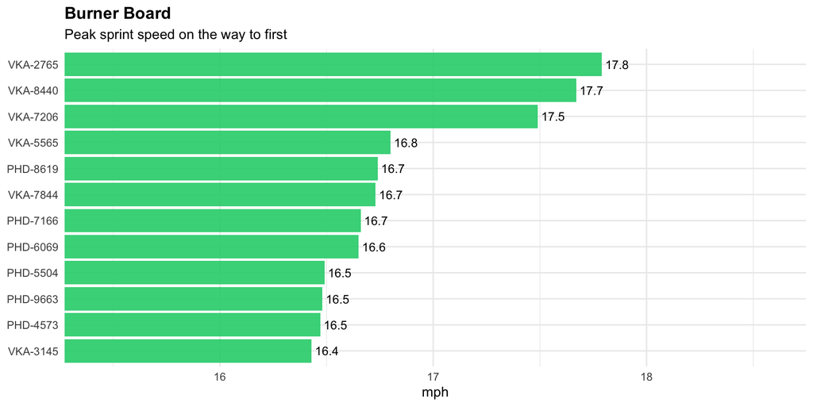

```r
ggplot(head(burner, 12), aes(x = reorder(player, top_mph), y = top_mph)) +
  geom_col(fill = GREEN, alpha = 0.9) +
  geom_text(aes(label = sprintf("%.1f", top_mph)), hjust = -0.15, size = 3.4) +
  coord_flip(ylim = c(min(head(burner,12)$top_mph) - 1, max(burner$top_mph) + 0.8)) +
  labs(title = "Burner Board", subtitle = "Peak sprint speed on the way to first",
       x = NULL, y = "mph") +
  theme_minimal(base_size = 11) +
  theme(plot.title = element_text(face = "bold"))
```

### Home-to-First Dash

Elapsed time from contact to the bag — measured as the frame the runner enters a 4-foot radius, not estimated from speed.

```r
dash <- runs %>%
  filter(!is.na(player), is.finite(time_to_first),
         time_to_first > 3, time_to_first < 7.5) %>%
  group_by(player) %>%
  summarise(best = min(time_to_first), avg = round(mean(time_to_first), 2),
            tries = n(), .groups = "drop") %>%
  mutate(grade = case_when(best < 4.2 ~ "ELITE",
                           best < 4.5 ~ "PLUS",
                           TRUE       ~ "AVERAGE")) %>%
  arrange(best)

dash %>% head(10) %>%
  kbl_or_note("Home-to-First Dash — beat the clock")
```

Home-to-First Dash — beat the clock

| player | best | avg | tries | grade |
| --- | --- | --- | --- | --- |
| VKA-6464 | 3.95 | 4.03 | 2 | ELITE |
| VKA-3145 | 4.20 | 4.22 | 2 | PLUS |
| PHD-5994 | 4.30 | 4.30 | 1 | PLUS |
| PHD-6069 | 4.30 | 4.30 | 1 | PLUS |
| PHD-7166 | 4.35 | 4.55 | 2 | PLUS |
| PHD-8619 | 4.40 | 4.45 | 2 | PLUS |
| VKA-2765 | 4.45 | 4.45 | 1 | PLUS |
| PHD-4573 | 4.50 | 4.50 | 1 | AVERAGE |
| PHD-7743 | 4.55 | 4.55 | 1 | AVERAGE |
| VKA-7844 | 4.65 | 4.65 | 1 | AVERAGE |

### Fastest Out of the Box

Acceleration over the first 1.5 seconds, which is the window where reaction and first step actually show up.

```r
box <- runs %>%
  filter(!is.na(player), is.finite(burst), burst > 0) %>%
  group_by(player) %>%
  summarise(best_burst = round(max(burst), 1), avg_burst = round(mean(burst), 1),
            n = n(), .groups = "drop") %>%
  filter(n >= scale_min(3)) %>%
  arrange(desc(best_burst))

box %>% head(10) %>%
  kbl_or_note("Fastest Out of the Box — ft/s gained in 1.5 seconds")
```

Fastest Out of the Box — ft/s gained in 1.5 seconds

| player | best_burst | avg_burst | n |
| --- | --- | --- | --- |
| VKA-7844 | 25.6 | 16.6 | 3 |
| VKA-8440 | 13.4 | 11.5 | 2 |
| PHD-8619 | 13.3 | 11.6 | 3 |
| PHD-9663 | 13.3 | 11.2 | 2 |
| VKA-6464 | 13.2 | 12.6 | 2 |
| VKA-3145 | 13.1 | 8.5 | 3 |
| PHD-7743 | 12.6 | 12.6 | 1 |
| VKA-5565 | 12.6 | 12.2 | 2 |
| PHD-4573 | 12.3 | 11.3 | 3 |
| VKA-2765 | 12.1 | 6.9 | 3 |

### Extra-Base Instinct

Speed and path efficiency when a runner actually takes an extra base.

```r
extra <- pbp %>%
  filter(outcome %in% c("double", "triple")) %>%
  select(game_string, play = last_play, outcome) %>%
  inner_join(runs, by = c("game_string", "play")) %>%
  filter(!is.na(player)) %>%
  group_by(player) %>%
  summarise(top_mph = max(sprint_mph), efficiency = round(mean(path_efficiency, na.rm = TRUE), 3),
            extra_bases = n(), triples = sum(outcome == "triple"), .groups = "drop") %>%
  arrange(desc(extra_bases), desc(top_mph))

extra %>% head(10) %>%
  kbl_or_note("Extra-Base Instinct — speed and route on doubles and triples")
```

Extra-Base Instinct — speed and route on doubles and triples

| player | top_mph | efficiency | extra_bases | triples |
| --- | --- | --- | --- | --- |
| PHD-8619 | 16.74 | 0.011 | 1 | 0 |
| VKA-7844 | 14.99 | 0.042 | 1 | 0 |

### Pickoff Jump

The data flags pickoff attempts but records **no outcome**, and there are no stolen-base or caught-stealing labels anywhere. So this reports the *measured* secondary lead and burst rather than a modelled steal probability — a real number beats an invented one.

```r
jump <- leads %>%
  group_by(runner) %>%
  summarise(plays = n(), avg_lead = round(mean(lead_ft), 1),
            max_lead = round(max(lead_ft), 1),
            avg_burst = round(mean(burst_mph, na.rm = TRUE), 1), .groups = "drop")

kbl_or_note(jump, "Pickoff Jump — measured secondary lead and burst",
            "No pickoff attempts in this sample — raise N_TRACK_GAMES.")
```

Pickoff Jump — measured secondary lead and burst

| runner | plays | avg_lead | max_lead | avg_burst |
| --- | --- | --- | --- | --- |
| R1 | 1 | 11.2 | 11.2 | 5.8 |

## Power & Hitting

### Statcast Smash

Ranked on the 90th percentile rather than the single hardest ball, so the leaderboard rewards repeatable damage.

```r
smash <- hits %>%
  filter(!is.na(player)) %>%
  group_by(player) %>%
  summarise(max_ev = max(exit_velo), p90_ev = round(quantile(exit_velo, 0.90), 1),
            avg_ev = round(mean(exit_velo), 1), balls = n(),
            team = first(team), .groups = "drop") %>%
  filter(balls >= scale_min(5)) %>%
  arrange(desc(p90_ev), desc(max_ev))

smash %>% head(10) %>%
  kbl_or_note("Statcast Smash — hardest hitters")
```

Statcast Smash — hardest hitters

| player | max_ev | p90_ev | avg_ev | balls | team |
| --- | --- | --- | --- | --- | --- |
| VKA-6464 | 122.5 | 119.8 | 108.8 | 2 | VKA |
| VKA-5565 | 115.4 | 112.2 | 99.2 | 2 | VKA |
| VKA-8440 | 112.1 | 107.9 | 91.0 | 2 | VKA |
| VKA-3145 | 107.7 | 107.7 | 107.7 | 1 | VKA |
| PHD-5504 | 106.4 | 105.1 | 99.9 | 2 | PHD |
| VKA-7844 | 111.9 | 104.7 | 86.0 | 3 | VKA |
| PHD-9663 | 105.1 | 103.9 | 99.0 | 2 | PHD |
| VKA-7206 | 104.4 | 100.5 | 84.8 | 2 | VKA |
| PHD-8619 | 100.6 | 99.0 | 92.6 | 2 | PHD |
| PHD-4573 | 102.0 | 95.7 | 71.7 | 3 | PHD |

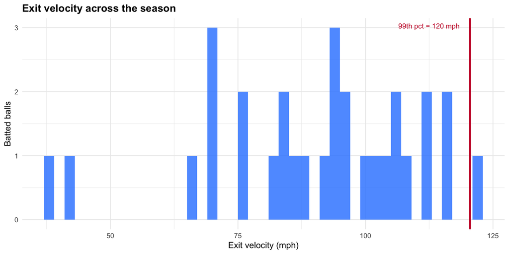

```r
ggplot(hits, aes(exit_velo)) +
  geom_histogram(binwidth = 2, fill = BLUE, alpha = 0.85) +
  geom_vline(xintercept = quantile(hits$exit_velo, 0.99), colour = RED, linewidth = 1) +
  annotate("text", x = quantile(hits$exit_velo, 0.99) - 2,
           y = Inf, vjust = 2, hjust = 1, colour = RED, size = 3.2,
           label = paste0("99th pct = ", round(quantile(hits$exit_velo, 0.99)), " mph")) +
  labs(title = "Exit velocity across the season",
       x = "Exit velocity (mph)", y = "Batted balls") +
  theme_minimal(base_size = 11) +
  theme(plot.title = element_text(face = "bold"))
```

### Moonshot Meter

```r
moonshot <- hits %>%
  filter(!is.na(player), launch >= 10, carry >= 150) %>%
  group_by(player) %>%
  summarise(longest = max(carry), avg = round(mean(carry), 1),
            flies = n(), team = first(team), .groups = "drop") %>%
  filter(flies >= scale_min(3)) %>%
  arrange(desc(longest))

moonshot %>% head(10) %>%
  kbl_or_note("Moonshot Meter — longest carry")
```

Moonshot Meter — longest carry

| player | longest | avg | flies | team |
| --- | --- | --- | --- | --- |
| PHD-9663 | 392.1 | 392.1 | 1 | PHD |
| PHD-8619 | 377.7 | 377.7 | 1 | PHD |
| VKA-8440 | 269.7 | 234.9 | 2 | VKA |
| PHD-5504 | 236.9 | 236.9 | 1 | PHD |
| PHD-0812 | 200.7 | 197.6 | 2 | PHD |
| VKA-7206 | 194.8 | 194.8 | 1 | VKA |
| PHD-7166 | 153.9 | 153.9 | 1 | PHD |

### Barrel Zone

A barrel is the sweet spot: exit velocity at least 95 mph with a launch angle between 20 and 35 degrees.

```r
hits <- hits %>%
  mutate(barrel = as.integer(exit_velo >= 95 & launch >= 20 & launch <= 35))

barrels <- hits %>%
  filter(!is.na(player)) %>%
  group_by(player) %>%
  summarise(barrels = sum(barrel), balls = n(),
            rate = round(100 * mean(barrel), 1), team = first(team),
            .groups = "drop") %>%
  filter(balls >= scale_min(8)) %>%
  arrange(desc(barrels), desc(rate))

barrels %>% head(10) %>%
  kbl_or_note("Barrel Zone — sweet-spot contact")
```

Barrel Zone — sweet-spot contact

| player | barrels | balls | rate | team |
| --- | --- | --- | --- | --- |
| PHD-0812 | 0 | 2 | 0 | PHD |
| PHD-4573 | 0 | 3 | 0 | PHD |
| PHD-5504 | 0 | 2 | 0 | PHD |
| PHD-5994 | 0 | 1 | 0 | PHD |
| PHD-7166 | 0 | 2 | 0 | PHD |
| PHD-8619 | 0 | 2 | 0 | PHD |
| PHD-9663 | 0 | 2 | 0 | PHD |
| VKA-0515 | 0 | 1 | 0 | VKA |
| VKA-2765 | 0 | 2 | 0 | VKA |
| VKA-3145 | 0 | 1 | 0 | VKA |

[figure not shown]

```r
ggplot(hits %>% filter(launch > -40, launch < 80),
       aes(exit_velo, launch)) +
  geom_hex(bins = 34) +
  scale_fill_gradient(low = "#1b2a3d", high = GOLD, trans = "log10") +
  annotate("rect", xmin = 95, xmax = max(hits$exit_velo), ymin = 20, ymax = 35,
           fill = NA, colour = RED, linewidth = 1) +
  annotate("text", x = 95, y = 42, label = "BARREL ZONE", colour = RED,
           fontface = "bold", size = 3.5, hjust = 0) +
  labs(title = "Where barrels live",
       x = "Exit velocity (mph)", y = "Launch angle (degrees)", fill = "Balls") +
  theme_minimal(base_size = 11) +
  theme(plot.title = element_text(face = "bold"))
```

### Launch Angle Rainbow

```r
rainbow <- hits %>%
  mutate(type = cut(launch, c(-90, 10, 25, 50, 90),
                    labels = c("ground ball", "line drive", "fly ball", "pop up")))

rainbow %>%
  filter(!is.na(type)) %>%
  group_by(type) %>%
  summarise(n = n(), avg_ev = round(mean(exit_velo), 1),
            avg_carry = round(mean(carry), 1),
            hr_rate = round(100 * mean(is_hr), 1), .groups = "drop") %>%
  kbl_or_note("Launch Angle Rainbow — what each batted-ball type produces")
```

Launch Angle Rainbow — what each batted-ball type produces

| type | n | avg_ev | avg_carry | hr_rate |
| --- | --- | --- | --- | --- |
| ground ball | 15 | 91.5 | 53.2 | 0 |
| line drive | 8 | 94.5 | 156.6 | 0 |
| fly ball | 2 | 79.0 | 293.5 | 0 |
| pop up | 5 | 83.1 | 127.7 | 0 |

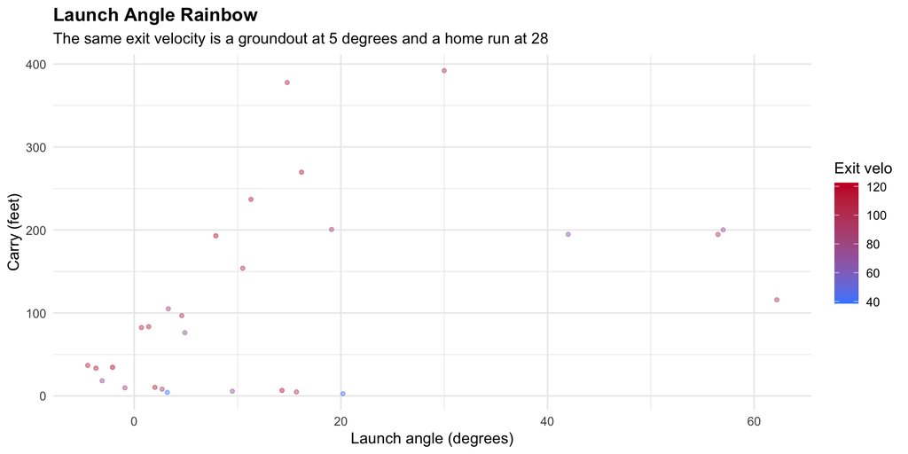

```r
ggplot(rainbow %>% filter(launch > -40, launch < 80, carry < 500),
       aes(launch, carry, colour = exit_velo)) +
  geom_point(alpha = 0.45, size = 1.1) +
  scale_colour_gradient(low = BLUE, high = RED) +
  labs(title = "Launch Angle Rainbow",
       subtitle = "The same exit velocity is a groundout at 5 degrees and a home run at 28",
       x = "Launch angle (degrees)", y = "Carry (feet)", colour = "Exit velo") +
  theme_minimal(base_size = 11) +
  theme(plot.title = element_text(face = "bold"))
```

### Clutch Contact

Contact quality weighted by what was at stake: $\frac{EV}{100}\times\sqrt{LI}$.

```r
clutch_contact <- pbp %>%
  select(game_string, play = last_play, inning, half_inning, batter,
         outcome, wpa, leverage) %>%
  inner_join(hits %>% select(game_string, play, exit_velo, carry),
             by = c("game_string", "play")) %>%
  mutate(score = round(exit_velo / 100 * sqrt(leverage), 3)) %>%
  arrange(desc(score))

clutch_contact %>%
  transmute(game = game_string, inning, half = half_inning, batter, outcome,
            exit_velo, leverage = round(leverage, 2),
            wpa = round(wpa, 3), score) %>%
  head(10) %>%
  kbl_or_note("Clutch Contact — hardest hit when it mattered most")
```

Clutch Contact — hardest hit when it mattered most

| game | inning | half | batter | outcome | exit_velo | leverage | wpa | score |
| --- | --- | --- | --- | --- | --- | --- | --- | --- |
| y1_d061_VKA_PHD | 9 | Top | VKA-8440 | single | 112.1 | 1.44 | -0.001 | 1.346 |
| y1_d061_VKA_PHD | 4 | Bottom | PHD-4573 | out | 102.0 | 1.29 | -0.024 | 1.157 |
| y1_d061_VKA_PHD | 4 | Top | VKA-2765 | out | 81.3 | 1.56 | -0.049 | 1.016 |
| y1_d061_VKA_PHD | 3 | Bottom | PHD-7166 | out | 96.1 | 1.04 | -0.021 | 0.978 |
| y1_d061_VKA_PHD | 3 | Top | VKA-6464 | out | 122.5 | 0.63 | -0.011 | 0.971 |
| y1_d061_VKA_PHD | 1 | Top | VKA-5565 | out | 115.4 | 0.68 | -0.012 | 0.954 |
| y1_d061_VKA_PHD | 4 | Top | VKA-7844 | out | 111.9 | 0.71 | -0.011 | 0.942 |
| y1_d061_VKA_PHD | 3 | Top | VKA-3145 | out | 107.7 | 0.74 | -0.012 | 0.925 |
| y1_d061_VKA_PHD | 4 | Bottom | PHD-9663 | out | 93.0 | 0.88 | -0.014 | 0.871 |
| y1_d061_VKA_PHD | 3 | Bottom | PHD-8619 | single | 84.5 | 1.02 | 0.067 | 0.853 |

## Pitching

### Radar Gun Live

```r
radar <- pitches %>%
  filter(!is.na(player)) %>%
  group_by(player) %>%
  summarise(max_velo = max(pitch_velo), avg_velo = round(mean(pitch_velo), 1),
            p90 = round(quantile(pitch_velo, 0.90), 1), pitches = n(),
            team = first(team), .groups = "drop") %>%
  filter(pitches >= scale_min(30)) %>%
  arrange(desc(max_velo), desc(avg_velo))

radar %>% head(10) %>%
  kbl_or_note("Radar Gun Live — pitch velocity leaders")
```

Radar Gun Live — pitch velocity leaders

| player | max_velo | avg_velo | p90 | pitches | team |
| --- | --- | --- | --- | --- | --- |
| PHD-4341 | 101.9 | 86.9 | 92.6 | 55 | PHD |
| PHD-8570 | 100.9 | 87.2 | 91.7 | 37 | PHD |
| VKA-1417 | 100.4 | 86.0 | 92.8 | 65 | VKA |
| VKA-5899 | 95.2 | 80.0 | 87.9 | 35 | VKA |
| PHD-6193 | 93.8 | 82.3 | 88.9 | 17 | PHD |
| PHD-0342 | 92.9 | 88.6 | 91.6 | 16 | PHD |

Readings above 103 mph are dropped during extraction as single-frame tracking spikes — the raw data contains a 193 mph artifact that would otherwise poison both the leaderboard and every percentile built from it.

### Velocity Heartbeat

Does a starter hold his gas? Per-pitch velocity with a rolling average.

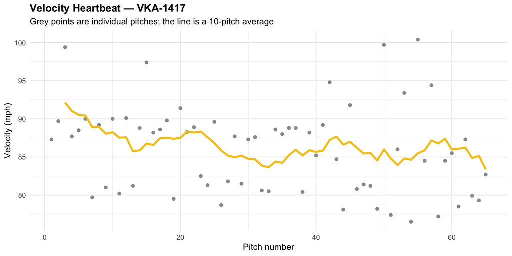

```r
# Take the pitcher who threw the most pitches in a single game
# Drop unmatched pitchers first -- a play missing from the lineup key comes
# back as NA, and an NA name would end up in the chart title
heartbeat_pick <- pitches %>%
  filter(!is.na(player)) %>%
  count(game_string, player, sort = TRUE) %>%
  slice(1)

hb_name <- if (nrow(heartbeat_pick) > 0) heartbeat_pick$player else "no pitcher found"

heartbeat <- pitches %>%
  filter(game_string == heartbeat_pick$game_string,
         player == heartbeat_pick$player) %>%
  arrange(play) %>%
  mutate(pitch_no = row_number(),
         # trailing 10-pitch average, written out rather than pulling in zoo
         rolling = sapply(seq_len(n()), function(i) {
           w <- pitch_velo[max(1, i - 9):i]
           if (length(w) >= 3) mean(w) else NA_real_
         }))

ggplot(heartbeat, aes(pitch_no)) +
  geom_point(aes(y = pitch_velo), colour = "grey60", size = 1.6) +
  geom_line(aes(y = rolling), colour = GOLD, linewidth = 1.2, na.rm = TRUE) +
  labs(title = paste0("Velocity Heartbeat — ", hb_name),
       subtitle = "Grey points are individual pitches; the line is a 10-pitch average",
       x = "Pitch number", y = "Velocity (mph)") +
  theme_minimal(base_size = 11) +
  theme(plot.title = element_text(face = "bold"))
```

```r
first10 <- mean(head(heartbeat$pitch_velo, 10))
last10  <- mean(tail(heartbeat$pitch_velo, 10))

tibble(metric = c("Pitches", "Average velocity", "First 10 average",
                  "Last 10 average", "Velocity held"),
       value = c(nrow(heartbeat), round(mean(heartbeat$pitch_velo), 1),
                 round(first10, 1), round(last10, 1),
                 round(last10 - first10, 1))) %>%
  kbl_or_note("Velocity Heartbeat summary")
```

Velocity Heartbeat summary

| metric | value |
| --- | --- |
| Pitches | 65.0 |
| Average velocity | 86.0 |
| First 10 average | 88.2 |
| Last 10 average | 83.4 |
| Velocity held | -4.9 |

### Effective Velocity

A pitcher who releases the ball closer to the plate shortens the flight and steals reaction time, so the ball plays faster than the gun says:

$$EV_{\text{eff}} = v \times \frac{60.5 - \bar{e}}{60.5 - e}$$

```r
league_ext <- median(pitches$extension, na.rm = TRUE)

eff_velo <- pitches %>%
  filter(is.finite(extension), extension > 0, extension < 12) %>%
  mutate(effective = round(pitch_velo * (RUBBER_FT - league_ext) /
                             (RUBBER_FT - extension), 1),
         gain = round(effective - pitch_velo, 1))

eff_velo %>%
  filter(!is.na(player)) %>%
  group_by(player) %>%
  summarise(avg_extension = round(mean(extension), 2),
            avg_velo = round(mean(pitch_velo), 1),
            avg_effective = round(mean(effective), 1),
            gain = round(mean(gain), 1), pitches = n(), .groups = "drop") %>%
  filter(pitches >= scale_min(30)) %>%
  arrange(desc(gain)) %>%
  head(10) %>%
  kbl_or_note(paste0("Effective Velocity — league median extension is ",
                       round(league_ext, 2), " ft"))
```

Effective Velocity — league median extension is 5.52 ft

| player | avg_extension | avg_velo | avg_effective | gain | pitches |
| --- | --- | --- | --- | --- | --- |
| VKA-5899 | 5.77 | 80.0 | 80.5 | 0.5 | 35 |
| PHD-4341 | 5.75 | 86.9 | 87.4 | 0.4 | 55 |
| VKA-1417 | 5.66 | 86.0 | 86.3 | 0.4 | 65 |
| PHD-8570 | 5.48 | 87.2 | 87.2 | 0.0 | 37 |
| PHD-6193 | 4.93 | 82.3 | 81.5 | -0.8 | 17 |
| PHD-0342 | 4.73 | 88.6 | 87.4 | -1.2 | 16 |

### Late Life

**Gravity is not movement.** Deviation from a straight line has two causes and only one is interesting: gravity drops a 90 mph pitch about 39 inches regardless of quality. Reporting that as break makes every pitch look filthy. Subtracting the $\tfrac{1}{2}gt^2$ component leaves **induced** vertical break — the aerodynamic part that actually separates pitch types.

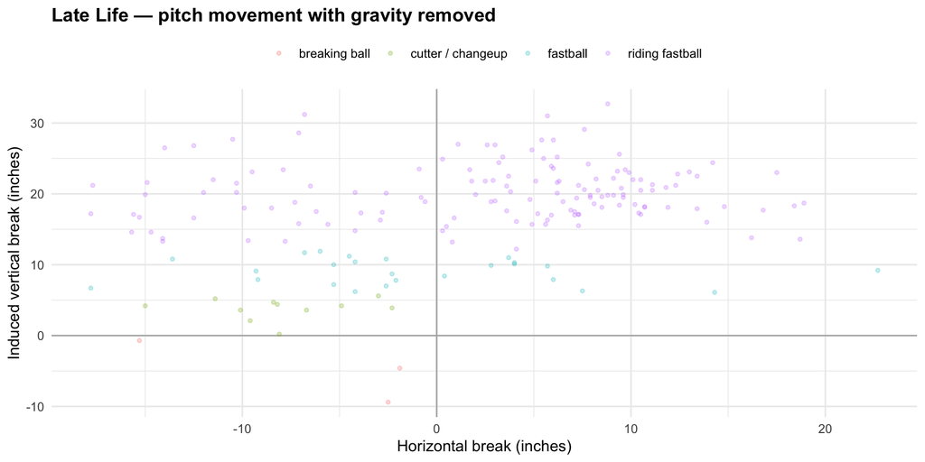

```r
movement <- pitches %>%
  filter(is.finite(induced_break), is.finite(horizontal_break),
         abs(induced_break) < 40, abs(horizontal_break) < 40) %>%
  mutate(shape = case_when(induced_break > 12 ~ "riding fastball",
                           induced_break > 6  ~ "fastball",
                           induced_break > 0  ~ "cutter / changeup",
                           TRUE               ~ "breaking ball"))

ggplot(movement, aes(horizontal_break, induced_break, colour = shape)) +
  geom_hline(yintercept = 0, colour = "grey70") +
  geom_vline(xintercept = 0, colour = "grey70") +
  geom_point(alpha = 0.25, size = 1) +
  labs(title = "Late Life — pitch movement with gravity removed",
       x = "Horizontal break (inches)", y = "Induced vertical break (inches)",
       colour = NULL) +
  theme_minimal(base_size = 11) +
  theme(plot.title = element_text(face = "bold"), legend.position = "top")
```

```r
movement %>%
  group_by(shape) %>%
  summarise(pitches = n(), avg_velo = round(mean(pitch_velo), 1),
            avg_ivb = round(mean(induced_break), 1),
            avg_hb = round(mean(horizontal_break), 1), .groups = "drop") %>%
  arrange(desc(avg_ivb)) %>%
  kbl_or_note("Late Life — pitch shapes separated by induced break")
```

Late Life — pitch shapes separated by induced break

| shape | pitches | avg_velo | avg_ivb | avg_hb |
| --- | --- | --- | --- | --- |
| riding fastball | 138 | 86.5 | 20.2 | 2.8 |
| fastball | 25 | 81.1 | 9.1 | -1.0 |
| cutter / changeup | 11 | 76.3 | 3.8 | -8.0 |
| breaking ball | 3 | 88.2 | -4.9 | -6.6 |

## Defense & Fielding

### The Robbery Meter

**METHOD:** Three physically meaningful features, engineered from tracking: how far the fielder had to travel (`route`), how long the ball was in the air (`hang`), and the closing speed those two imply. Route and hang are the physics; their ratio is what separates a routine fly from a highlight.

```r
catch_data <- catches %>%
  filter(hang > 0.4, route >= 0, route < 160) %>%
  mutate(required_speed = pmin(route / hang, 45))

catch_model <- glm(catch_made ~ route + hang + required_speed,
                   family = binomial(), data = catch_data)

catch_data <- catch_data %>%
  mutate(catch_prob = as.numeric(predict(catch_model, type = "response")),
         oae = catch_made - catch_prob,
         robbery = if_else(catch_made == 1, 100 * (1 - catch_prob), 0),
         # a play is most fun to vote on when the model is least sure
         suspense = 1 - abs(2 * (catch_prob - 0.5)))

catch_acc <- round(mean((catch_data$catch_prob >= 0.5) == (catch_data$catch_made == 1)), 3)

tibble(metric = c("Catch opportunities", "Base catch rate", "Accuracy", "Brier score"),
       value = c(comma(nrow(catch_data)), round(mean(catch_data$catch_made), 3),
                 catch_acc,
                 round(mean((catch_data$catch_prob - catch_data$catch_made)^2), 3))) %>%
  kbl_or_note("Robbery Meter — catch probability model")
```

Robbery Meter — catch probability model

| metric | value |
| --- | --- |
| Catch opportunities | 28 |
| Base catch rate | 1 |
| Accuracy | 1 |
| Brier score | 0 |

[figure not shown]

```r
# The model as a fan would read it
grid <- expand_grid(route = seq(0, 130, 2), hang = c(2, 3, 4, 5)) %>%
  mutate(required_speed = pmin(route / hang, 45))
grid$catch_prob <- as.numeric(predict(catch_model, grid, type = "response"))

ggplot(grid, aes(route, catch_prob, colour = factor(hang))) +
  geom_line(linewidth = 1.2) +
  scale_y_continuous(labels = percent) +
  labs(title = "The Robbery Meter",
       subtitle = "A 60 ft route is routine with 5 seconds of hang time, a coin flip with 3",
       x = "Route distance (feet)", y = "Catch probability",
       colour = "Hang time (s)") +
  theme_minimal(base_size = 11) +
  theme(plot.title = element_text(face = "bold"), legend.position = "top")
```

```r
# Outs Above Expected: catches made beyond what an average defender makes
oae <- catch_data %>%
  filter(!is.na(player)) %>%
  group_by(player) %>%
  summarise(chances = n(), made = sum(catch_made),
            expected = round(sum(catch_prob), 1), oae = round(sum(oae), 2),
            pos = first(pos), team = first(team), .groups = "drop") %>%
  filter(chances >= scale_min(12)) %>%
  arrange(desc(oae))

oae %>% head(10) %>%
  kbl_or_note("Outs Above Expected — the best gloves in the league")
```

Outs Above Expected — the best gloves in the league

| player | chances | made | expected | oae | pos | team |
| --- | --- | --- | --- | --- | --- | --- |
| PHD-0812 | 3 | 3 | 3 | 0 | SS | PHD |
| PHD-5994 | 3 | 3 | 3 | 0 | RF | PHD |
| PHD-7166 | 2 | 2 | 2 | 0 | LF | PHD |
| PHD-7743 | 6 | 6 | 6 | 0 | 2B | PHD |
| PHD-8619 | 1 | 1 | 1 | 0 | CF | PHD |
| VKA-3145 | 1 | 1 | 1 | 0 | 2B | VKA |
| VKA-5565 | 4 | 4 | 4 | 0 | CF | VKA |
| VKA-6464 | 3 | 3 | 3 | 0 | SS | VKA |
| VKA-7206 | 2 | 2 | 2 | 0 | RF | VKA |
| VKA-7844 | 3 | 3 | 3 | 0 | LF | VKA |

### Web Gem of the Game

```r
web_gems <- catch_data %>%
  filter(catch_made == 1, !is.na(player)) %>%
  arrange(catch_prob) %>%
  transmute(game = game_string, play, player, pos, route, hang,
            catch_prob = round(catch_prob, 3), robbery = round(robbery, 1))

web_gems %>% head(10) %>%
  kbl_or_note("Web Gems — the least likely catches of the season")
```

Web Gems — the least likely catches of the season

| game | play | player | pos | route | hang | catch_prob | robbery |
| --- | --- | --- | --- | --- | --- | --- | --- |
| y1_d061_VKA_PHD | 2 | PHD-7743 | 2B | 19.9 | 2.00 | 1 | 0 |
| y1_d061_VKA_PHD | 3 | PHD-7743 | 2B | 14.3 | 2.15 | 1 | 0 |
| y1_d061_VKA_PHD | 8 | PHD-0812 | SS | 46.7 | 4.30 | 1 | 0 |
| y1_d061_VKA_PHD | 11 | VKA-5565 | CF | 93.0 | 5.85 | 1 | 0 |
| y1_d061_VKA_PHD | 22 | VKA-7844 | LF | 59.1 | 5.15 | 1 | 0 |
| y1_d061_VKA_PHD | 25 | PHD-7743 | 2B | 4.8 | 1.85 | 1 | 0 |
| y1_d061_VKA_PHD | 28 | PHD-5994 | RF | 78.3 | 5.95 | 1 | 0 |
| y1_d061_VKA_PHD | 35 | PHD-7166 | LF | 7.8 | 2.55 | 1 | 0 |
| y1_d061_VKA_PHD | 37 | VKA-6464 | SS | 2.1 | 1.10 | 1 | 0 |
| y1_d061_VKA_PHD | 42 | VKA-7206 | RF | 23.8 | 3.85 | 1 | 0 |

### Outfield Cannons

```r
cannons <- throws %>%
  filter(!is.na(player)) %>%
  group_by(player) %>%
  summarise(max_throw = max(throw_velo), avg_throw = round(mean(throw_velo), 1),
            throws = n(), pos = first(pos), team = first(team), .groups = "drop") %>%
  filter(throws >= scale_min(3)) %>%
  arrange(desc(max_throw))

cannons %>% head(10) %>%
  kbl_or_note("Outfield Cannons — arm strength")
```

Outfield Cannons — arm strength

| player | max_throw | avg_throw | throws | pos | team |
| --- | --- | --- | --- | --- | --- |
| VKA-5565 | 87.1 | 73.1 | 3 | CF | VKA |
| PHD-6069 | 82.4 | 82.4 | 1 | 3B | PHD |
| PHD-7166 | 82.1 | 82.1 | 1 | LF | PHD |
| PHD-0812 | 79.0 | 79.0 | 1 | SS | PHD |
| VKA-7844 | 78.8 | 65.3 | 3 | LF | VKA |
| VKA-0515 | 73.2 | 72.2 | 4 | 3B | VKA |
| VKA-6464 | 72.7 | 71.8 | 2 | SS | VKA |
| PHD-7743 | 70.6 | 66.3 | 6 | 2B | PHD |
| PHD-4573 | 67.4 | 67.4 | 1 | 1B | PHD |
| PHD-5994 | 64.1 | 56.8 | 2 | RF | PHD |

### Ground Crew Range

```r
range_lb <- catch_data %>%
  filter(catch_made == 1, !is.na(player)) %>%
  group_by(player) %>%
  summarise(avg_route = round(mean(route), 1), max_route = max(route),
            top_closing = round(max(closing, na.rm = TRUE) * MPH, 1),
            efficiency = round(mean(efficiency, na.rm = TRUE), 3),
            catches = n(), pos = first(pos), .groups = "drop") %>%
  filter(catches >= scale_min(8)) %>%
  arrange(desc(avg_route))

range_lb %>% head(10) %>%
  kbl_or_note("Ground Crew Range — ground covered per catch")
```

Ground Crew Range — ground covered per catch

| player | avg_route | max_route | top_closing | efficiency | catches | pos |
| --- | --- | --- | --- | --- | --- | --- |
| VKA-5565 | 81.0 | 93.0 | 17.2 | 0.944 | 4 | CF |
| PHD-8619 | 70.0 | 70.0 | 13.8 | 0.780 | 1 | CF |
| PHD-5994 | 50.3 | 78.3 | 15.1 | 0.960 | 3 | RF |
| VKA-7844 | 48.1 | 65.5 | 15.5 | 0.923 | 3 | LF |
| PHD-7166 | 39.8 | 71.8 | 16.0 | 0.703 | 2 | LF |
| VKA-6464 | 22.9 | 61.9 | 11.6 | 0.886 | 3 | SS |
| PHD-0812 | 21.9 | 46.7 | 11.6 | 0.961 | 3 | SS |
| VKA-7206 | 20.7 | 23.8 | 7.4 | 0.972 | 2 | RF |
| PHD-7743 | 13.8 | 26.2 | 13.6 | 0.893 | 6 | 2B |
| VKA-3145 | 3.8 | 3.8 | 3.5 | 0.932 | 1 | 2B |

### Double-Play Ballet

Pivot time: glove to release for the middle infielder on the turn.

```r
pivot_summary <- pivots %>%
  group_by(pos) %>%
  summarise(turns = n(), fastest = min(pivot), avg = round(mean(pivot), 2),
            .groups = "drop")

kbl_or_note(pivot_summary, "Double-Play Ballet — pivot time by position",
            "No double-play turns in this sample — raise N_TRACK_GAMES.")
```

Double-Play Ballet — pivot time by position

| pos | turns | fastest | avg |
| --- | --- | --- | --- |
| 2B | 8 | 0.7 | 0.96 |
| SS | 4 | 0.8 | 1.16 |

### Pop-Time Pipeline

```r
pop_summary <- if (nrow(pops) == 0) pops else {
  pops %>%
    summarise(attempts = n(), fastest_exchange = min(exchange),
              avg_exchange = round(mean(exchange), 2),
              avg_throw = round(mean(throw_velo, na.rm = TRUE), 1),
              hardest_throw = round(max(throw_velo, na.rm = TRUE), 1))
}

kbl_or_note(pop_summary, "Pop-Time Pipeline — catcher exchange and throw",
            "No throws to second in this sample — raise N_TRACK_GAMES.")
```

*No throws to second in this sample — raise N_TRACK_GAMES.*

## Fan-Interactive Games

### Catch or No Catch?

```r
vote_catch <- catch_data %>%
  filter(catch_prob >= 0.25, catch_prob <= 0.75) %>%
  arrange(desc(suspense)) %>%
  transmute(game = game_string, play, fielder = pos, route, hang,
            catch_prob = round(catch_prob, 3),
            answer = if_else(catch_made == 1, "CAUGHT", "DROPS"),
            suspense = round(suspense, 3))

vote_catch %>% head(8) %>%
  kbl_or_note("Catch or No Catch? — plays the model is least sure about")
```

*No qualifying plays in this sample.*

### Out or Safe?

A bang-bang play at first: compare when the throw would arrive against when the runner did.

```r
close_plays <- throws %>%
  select(game_string, play, fielder_id, throw_velo, transfer) %>%
  inner_join(runs %>% select(game_string, play, time_to_first, sprint_mph),
             by = c("game_string", "play")) %>%
  filter(is.finite(time_to_first), is.finite(throw_velo)) %>%
  # rough flight time of the throw from the infield to the bag
  mutate(throw_time = 90 / (throw_velo / MPH),
         margin = round(time_to_first - (transfer + throw_time), 3),
         verdict = if_else(margin < 0, "SAFE", "OUT")) %>%
  arrange(abs(margin))

close_plays %>%
  transmute(game = game_string, play, sprint_mph, time_to_first,
            throw_velo, margin, verdict) %>%
  head(8) %>%
  kbl_or_note("Out or Safe? — the tightest races at first base")
```

Out or Safe? — the tightest races at first base

| game | play | sprint_mph | time_to_first | throw_velo | margin | verdict |
| --- | --- | --- | --- | --- | --- | --- |
| y1_d061_VKA_PHD | 58 | 16.34 | 3.95 | 82.4 | 1.505 | OUT |
| y1_d061_VKA_PHD | 42 | 16.48 | 4.85 | 58.2 | 1.796 | OUT |
| y1_d061_VKA_PHD | 96 | 15.79 | 4.50 | 71.8 | 1.945 | OUT |
| y1_d061_VKA_PHD | 88 | 15.95 | 5.05 | 53.9 | 2.012 | OUT |
| y1_d061_VKA_PHD | 123 | 15.37 | 4.35 | 73.0 | 2.109 | OUT |
| y1_d061_VKA_PHD | 115 | 15.51 | 4.55 | 73.2 | 2.112 | OUT |
| y1_d061_VKA_PHD | 64 | 16.13 | 5.10 | 60.8 | 2.291 | OUT |
| y1_d061_VKA_PHD | 191 | 15.65 | 4.10 | 79.0 | 2.323 | OUT |

### Guess the Gun

```r
guess_gun <- pitches %>%
  filter(pitch_velo >= 95) %>%
  arrange(desc(pitch_velo)) %>%
  mutate(low = floor(pitch_velo / 3) * 3 - 3,
         option_a = paste0(low, "-", low + 2),
         option_b = paste0(low + 3, "-", low + 5),
         option_c = paste0(low + 6, "-", low + 8),
         answer = case_when(pitch_velo < low + 3 ~ option_a,
                            pitch_velo < low + 6 ~ option_b,
                            TRUE ~ option_c))

guess_gun %>%
  transmute(game = game_string, play, pitcher = player,
            option_a, option_b, option_c, actual = pitch_velo, answer) %>%
  head(8) %>%
  kbl_or_note("Guess the Gun — three buckets straddling the real reading")
```

Guess the Gun — three buckets straddling the real reading

| game | play | pitcher | option_a | option_b | option_c | actual | answer |
| --- | --- | --- | --- | --- | --- | --- | --- |
| y1_d061_VKA_PHD | 2 | PHD-4341 | 96-98 | 99-101 | 102-104 | 101.9 | 99-101 |
| y1_d061_VKA_PHD | 137 | PHD-8570 | 96-98 | 99-101 | 102-104 | 100.9 | 99-101 |
| y1_d061_VKA_PHD | 113 | VKA-1417 | 96-98 | 99-101 | 102-104 | 100.4 | 99-101 |
| y1_d061_VKA_PHD | 96 | VKA-1417 | 96-98 | 99-101 | 102-104 | 99.7 | 99-101 |
| y1_d061_VKA_PHD | 11 | VKA-1417 | 96-98 | 99-101 | 102-104 | 99.4 | 99-101 |
| y1_d061_VKA_PHD | 35 | PHD-4341 | 93-95 | 96-98 | 99-101 | 97.7 | 96-98 |
| y1_d061_VKA_PHD | 37 | VKA-1417 | 93-95 | 96-98 | 99-101 | 97.4 | 96-98 |
| y1_d061_VKA_PHD | 157 | VKA-5899 | 90-92 | 93-95 | 96-98 | 95.2 | 93-95 |

### How Far Did It Go?

```r
how_far <- hits %>%
  filter(carry >= 330) %>%
  arrange(desc(carry)) %>%
  mutate(low = floor(carry / 25) * 25 - 25,
         option_a = paste0(low, "-", low + 24, " ft"),
         option_b = paste0(low + 25, "-", low + 49, " ft"),
         option_c = paste0(low + 50, "+ ft"),
         answer = case_when(carry < low + 25 ~ option_a,
                            carry < low + 50 ~ option_b,
                            TRUE ~ option_c))

how_far %>%
  transmute(game = game_string, play, batter = player, exit_velo,
            option_a, option_b, option_c, actual = carry, answer) %>%
  head(8) %>%
  kbl_or_note("How Far Did It Go? — 25-foot buckets")
```

How Far Did It Go? — 25-foot buckets

| game | play | batter | exit_velo | option_a | option_b | option_c | actual | answer |
| --- | --- | --- | --- | --- | --- | --- | --- | --- |
| y1_d061_VKA_PHD | 91 | PHD-9663 | 93.0 | 350-374 ft | 375-399 ft | 400+ ft | 392.1 | 375-399 ft |
| y1_d061_VKA_PHD | 11 | PHD-8619 | 100.6 | 350-374 ft | 375-399 ft | 400+ ft | 377.7 | 375-399 ft |

### Beat the Burner

The target is how long the runner needed to cover 90 feet at his peak speed.

```r
beat_burner <- runs %>%
  filter(!is.na(player)) %>%
  arrange(desc(sprint_mph)) %>%
  mutate(target_seconds = round(90 / (sprint_mph / MPH), 2),
         league_pct = round(100 * percent_rank(sprint_mph), 1))

beat_burner %>%
  transmute(game = game_string, play, runner = player, sprint_mph,
            target_seconds, league_pct) %>%
  head(8) %>%
  kbl_or_note("Beat the Burner — can a fan tap faster than he runs?")
```

Beat the Burner — can a fan tap faster than he runs?

| game | play | runner | sprint_mph | target_seconds | league_pct |
| --- | --- | --- | --- | --- | --- |
| y1_d061_VKA_PHD | 224 | VKA-2765 | 17.79 | 3.45 | 100.0 |
| y1_d061_VKA_PHD | 228 | VKA-8440 | 17.67 | 3.47 | 98.6 |
| y1_d061_VKA_PHD | 221 | VKA-7206 | 17.49 | 3.51 | 97.1 |
| y1_d061_VKA_PHD | 226 | VKA-8440 | 17.38 | 3.53 | 95.7 |
| y1_d061_VKA_PHD | 2 | VKA-5565 | 16.80 | 3.65 | 94.3 |
| y1_d061_VKA_PHD | 11 | PHD-8619 | 16.74 | 3.67 | 92.9 |
| y1_d061_VKA_PHD | 3 | VKA-7844 | 16.73 | 3.67 | 91.4 |
| y1_d061_VKA_PHD | 8 | VKA-7206 | 16.71 | 3.67 | 90.0 |

## Composite & Storytelling

### Five-Tool Scoreboard

Speed, power and arm are measured in different things, so each is converted to a **league percentile first** and then averaged. That makes the blend honest and the output instantly legible: 97 means better than 97% of the league.

```r
five_tool <- burner %>%
  select(player, speed = top_mph) %>%
  full_join(smash %>% select(player, power = max_ev), by = "player") %>%
  full_join(cannons %>% select(player, arm = max_throw), by = "player") %>%
  mutate(speed_pct = round(100 * percent_rank(speed), 1),
         power_pct = round(100 * percent_rank(power), 1),
         arm_pct   = round(100 * percent_rank(arm), 1),
         tools = as.integer(!is.na(speed_pct)) + as.integer(!is.na(power_pct)) +
                 as.integer(!is.na(arm_pct)),
         score = round(rowMeans(cbind(speed_pct, power_pct, arm_pct), na.rm = TRUE), 1),
         team = str_split_i(player, "-", 1)) %>%
  filter(tools >= 2) %>%
  arrange(desc(score))

five_tool %>% head(10) %>%
  select(player, team, speed, power, arm, speed_pct, power_pct, arm_pct, tools, score) %>%
  kbl_or_note("Five-Tool Scoreboard — percentile blend of speed, power and arm")
```

Five-Tool Scoreboard — percentile blend of speed, power and arm

| player | team | speed | power | arm | speed_pct | power_pct | arm_pct | tools | score |
| --- | --- | --- | --- | --- | --- | --- | --- | --- | --- |
| VKA-5565 | VKA | 16.80 | 115.4 | 87.1 | 82.4 | 92.9 | 100.0 | 3 | 91.8 |
| VKA-8440 | VKA | 17.67 | 112.1 | NA | 94.1 | 85.7 | NA | 2 | 89.9 |
| PHD-6069 | PHD | 16.65 | NA | 82.4 | 58.8 | NA | 90.9 | 2 | 74.8 |
| VKA-7844 | VKA | 16.73 | 111.9 | 78.8 | 70.6 | 78.6 | 63.6 | 3 | 70.9 |
| PHD-5504 | PHD | 16.49 | 106.4 | NA | 52.9 | 64.3 | NA | 2 | 58.6 |
| PHD-7166 | PHD | 16.66 | 96.1 | 82.1 | 64.7 | 28.6 | 81.8 | 3 | 58.4 |
| VKA-2765 | VKA | 17.79 | 93.9 | NA | 100.0 | 14.3 | NA | 2 | 57.1 |
| VKA-6464 | VKA | 16.34 | 122.5 | 72.7 | 23.5 | 100.0 | 45.5 | 3 | 56.3 |
| PHD-8619 | PHD | 16.74 | 100.6 | NA | 76.5 | 35.7 | NA | 2 | 56.1 |
| PHD-9663 | PHD | 16.48 | 105.1 | NA | 47.1 | 57.1 | NA | 2 | 52.1 |

### Player of the Game Engine

Not a box score line — a **win probability** line. Batters are credited with their WPA; pitchers with the negative of the WPA they allowed.

```r
potg <- bind_rows(
  pbp %>% group_by(game_string, player = batter) %>%
    summarise(role = "batting", pa = n(), wpa = sum(wpa),
              hits = sum(outcome %in% c("single","double","triple","home_run")),
              rbi = sum(runs), .groups = "drop"),
  pbp %>% group_by(game_string, player = pitcher) %>%
    summarise(role = "pitching", pa = n(), wpa = -sum(wpa),
              hits = NA_integer_, rbi = NA_integer_, .groups = "drop")) %>%
  mutate(score = round(100 * wpa, 1)) %>%
  arrange(desc(wpa))

potg %>% head(10) %>%
  transmute(game = game_string, player, role, pa, wpa = round(wpa, 3), score) %>%
  kbl_or_note("Player of the Game — biggest single-game win contributions")
```

Player of the Game — biggest single-game win contributions

| game | player | role | pa | wpa | score |
| --- | --- | --- | --- | --- | --- |
| y1_d083_NXS_ARN | ARN-1503 | batting | 6 | 0.582 | 58.2 |
| y1_d072_URD_ARN | URD-2640 | pitching | 2 | 0.579 | 57.9 |
| y1_d066_VAS_PHD | VAS-6483 | pitching | 3 | 0.575 | 57.5 |
| y1_d077.5_PHD_VAS | PHD-8619 | batting | 4 | 0.482 | 48.2 |
| y1_d074_AIP_ARN | AIP-2104 | pitching | 1 | 0.384 | 38.4 |
| y1_d068_SQF_ARN | SQF-1665 | batting | 5 | 0.380 | 38.0 |
| y1_d074_XPO_PHD | XPO-6109 | pitching | 24 | 0.366 | 36.6 |
| y1_d072_XPO_PHD | PHD-6193 | pitching | 4 | 0.340 | 34.0 |
| y1_d075_XPO_PHD | XPO-2578 | pitching | 18 | 0.308 | 30.8 |
| y1_d083_NXS_ARN | ARN-5007 | batting | 6 | 0.305 | 30.5 |

### Rivalry Radar

```r
rivalry <- pbp %>%
  left_join(hits %>% select(game_string, play, exit_velo),
            by = c("game_string", "last_play" = "play")) %>%
  group_by(team = batting_team) %>%
  summarise(games = n_distinct(game_string), pa = n(),
            runs_per_game = round(sum(runs) / n_distinct(game_string), 2),
            hr = sum(outcome == "home_run"),
            avg_exit_velo = round(mean(exit_velo, na.rm = TRUE), 1),
            high_leverage_pa = sum(leverage >= 2),
            .groups = "drop") %>%
  arrange(desc(runs_per_game))

rivalry %>% head(12) %>%
  kbl_or_note("Rivalry Radar — team tale of the tape from tracking")
```

Rivalry Radar — team tale of the tape from tracking

| team | games | pa | runs_per_game | hr | avg_exit_velo | high_leverage_pa |
| --- | --- | --- | --- | --- | --- | --- |
| XPO | 4 | 168 | 6.25 | 3 | NaN | 18 |
| ARN | 8 | 297 | 6.12 | 13 | NaN | 38 |
| NXS | 1 | 42 | 6.00 | 1 | NaN | 10 |
| URD | 1 | 48 | 5.00 | 0 | NaN | 14 |
| AIP | 2 | 60 | 4.50 | 4 | NaN | 8 |
| SQF | 4 | 138 | 4.50 | 4 | NaN | 7 |
| PHD | 16 | 568 | 3.69 | 13 | 85.8 | 60 |
| VAS | 5 | 151 | 3.40 | 4 | NaN | 17 |
| JJP | 3 | 116 | 3.33 | 4 | NaN | 11 |
| ANI | 1 | 21 | 3.00 | 1 | NaN | 0 |
| VKA | 4 | 135 | 1.75 | 2 | 92.3 | 8 |
| NLG | 1 | 12 | 0.00 | 0 | NaN | 1 |

### Prospect Spotlight

```r
spotlight_player <- five_tool$player[1]

tibble(tool = c("Speed", "Power", "Arm"),
       value = c(five_tool$speed[1], five_tool$power[1], five_tool$arm[1]),
       percentile = c(five_tool$speed_pct[1], five_tool$power_pct[1],
                      five_tool$arm_pct[1])) %>%
  mutate(grade = case_when(percentile >= 97 ~ "ELITE",
                           percentile >= 85 ~ "PLUS-PLUS",
                           percentile >= 70 ~ "PLUS",
                           percentile >= 45 ~ "AVERAGE",
                           TRUE ~ "BELOW AVG")) %>%
  kbl_or_note(paste0("Prospect Spotlight — ", spotlight_player))
```

Prospect Spotlight — VKA-5565

| tool | value | percentile | grade |
| --- | --- | --- | --- |
| Speed | 16.8 | 82.4 | PLUS |
| Power | 115.4 | 92.9 | PLUS-PLUS |
| Arm | 87.1 | 100.0 | ELITE |

# Part 4 — The Play Explorer

Everything above is a leaderboard. This is the scoreboard: pick a play from the win-probability chart and watch it happen, with its metrics underneath.

```r
# Tracking for a whole season is far too large to embed, so the explorer only
# carries games we actually extracted -- ranked by drama, the biggest single
# swing in each -- and at most three of them.
explorer_games <- pbp %>%
  filter(game_string %in% track_games) %>%
  group_by(game_string) %>%
  summarise(drama = max(abs(wpa)), .groups = "drop") %>%
  arrange(desc(drama)) %>%
  head(min(3, length(track_games))) %>%
  pull(game_string)

explorer_pbp <- pbp %>% filter(game_string %in% explorer_games)
```

```r
# Frames for the plays we can replay, trimmed to the live ball and rounded to a
# tenth of a foot -- finer precision is invisible on screen and triples the size
build_frames <- function(gs) {

  keep <- explorer_pbp %>% filter(game_string == gs) %>% pull(last_play)

  bp <- ball_positions %>% filter(game_string == gs) %>% collect() %>%
    mutate(across(everything(), as.numeric)) %>% filter(play_per_game %in% keep)
  pp <- player_positions %>% filter(game_string == gs) %>% collect() %>%
    mutate(across(everything(), as.numeric)) %>%
    filter(play_per_game %in% keep, player_id <= 13)
  ev <- ball_events %>% filter(game_string == gs) %>% collect() %>%
    mutate(across(c(play_per_game, timestamp, ball_eventcode), as.numeric)) %>%
    filter(play_per_game %in% keep)

  out <- list()
  for (pl in keep) {
    b <- bp %>% filter(play_per_game == pl) %>% arrange(timestamp)
    if (nrow(b) < 2) next
    e <- ev %>% filter(play_per_game == pl)

    t0 <- if (any(e$ball_eventcode == EV[["PITCH"]])) {
      min(e$timestamp[e$ball_eventcode == EV[["PITCH"]]]) - 400
    } else min(b$timestamp)
    t1 <- if (any(e$ball_eventcode == EV[["END"]])) {
      max(e$timestamp[e$ball_eventcode == EV[["END"]]]) + 800
    } else max(b$timestamp)

    b <- b %>% filter(timestamp >= t0, timestamp <= t1)
    if (nrow(b) < 2) next
    ts <- b$timestamp

    players <- list()
    for (pid in sort(unique(pp$player_id[pp$play_per_game == pl]))) {
      trk <- pp %>% filter(play_per_game == pl, player_id == pid) %>%
        arrange(timestamp)
      if (nrow(trk) < 2) next
      players[[as.character(pid)]] <- list(
        x = round(approx(trk$timestamp, trk$field_x, ts, rule = 2)$y, 1),
        y = round(approx(trk$timestamp, trk$field_y, ts, rule = 2)$y, 1))
    }

    out[[as.character(pl)]] <- list(
      t  = round(ts - ts[1]),
      bx = round(b$ball_position_x, 1),
      by = round(b$ball_position_y, 1),
      bz = round(b$ball_position_z, 1),
      players = players,
      marks = e %>%
        filter(ball_eventcode %in% c(1, 2, 3, 4, 5, 10, 11, 16)) %>%
        transmute(t = round(timestamp - ts[1]), code = ball_eventcode))
  }
  out
}

frames <- cached("explorer_frames", {
  setNames(lapply(explorer_games, build_frames), explorer_games)
})
```

```r
# Join every metric we computed onto the plays the explorer can show
explorer_rows <- explorer_pbp %>%
  left_join(hits %>% select(game_string, play, exit_velo, launch, carry, barrel),
            by = c("game_string", "last_play" = "play")) %>%
  left_join(pitches %>% select(game_string, play, pitch_velo, extension,
                               induced_break, horizontal_break),
            by = c("game_string", "last_play" = "play")) %>%
  left_join(runs %>% select(game_string, play, sprint_mph, time_to_first, burst),
            by = c("game_string", "last_play" = "play")) %>%
  left_join(catch_data %>% select(game_string, play, pos, route, hang,
                                  catch_prob, robbery),
            by = c("game_string", "last_play" = "play")) %>%
  left_join(throws %>% select(game_string, play, throw_velo, transfer),
            by = c("game_string", "last_play" = "play")) %>%
  mutate(wp_home = if_else(half_inning == "Bottom", wp_after, 1 - wp_after))

# Every pitch thrown in each at-bat, for the tunnel view. A play is one pitch,
# so the at-bat's pitches are the plays between its first and last.
pitch_seq <- explorer_pbp %>%
  # key_play is made with mutate, not select. Naming a column twice in one
  # select() -- once renamed, once not -- keeps only one of them, and the
  # other silently disappears.
  mutate(key_play = last_play) %>%
  select(game_string, key_play, first_play, last_play) %>%
  inner_join(pitches %>% select(game_string, play, pitch_velo, plate_x, plate_z,
                                induced_break, horizontal_break),
             by = "game_string", relationship = "many-to-many") %>%
  filter(play >= first_play, play <= last_play,
         !is.na(plate_x), !is.na(plate_z)) %>%
  arrange(game_string, key_play, play) %>%
  group_by(game_string, key_play) %>%
  mutate(pitch_no = row_number()) %>%
  ungroup()

# Keyed "game play" so the browser can look up an at-bat's pitches directly
pitch_map <- split(pitch_seq, paste(pitch_seq$game_string, pitch_seq$key_play))
pitch_map <- lapply(pitch_map, function(d) {
  d %>% transmute(n = pitch_no, x = round(plate_x, 3), z = round(plate_z, 3),
                  velo = pitch_velo, ivb = induced_break, hb = horizontal_break)
})

# Strike zone, calibrated from where pitches actually cross rather than assumed
# (z = 0 in this coordinate system is a datum, not the ground)
zone_src <- pitches %>% filter(!is.na(plate_z))

zone <- if (nrow(zone_src) >= 50) {
  list(bottom = round(unname(quantile(zone_src$plate_z, 0.12)), 2),
       top    = round(unname(quantile(zone_src$plate_z, 0.88)), 2),
       half_width = 0.83)
} else {
  # too few tracked crossings to calibrate; fall back to a nominal zone
  list(bottom = 1.5, top = 3.4, half_width = 0.83)
}

payload <- list(
  games = lapply(explorer_games, function(g) {
    m <- game_info %>% filter(game_string == g) %>% slice(1)
    list(id = g, home = m$home_team, away = m$away_team)
  }),
  zone = zone,
  pitch_map = pitch_map,
  plays = explorer_rows %>%
    transmute(game = game_string, play = last_play, inning, half = half_inning,
              batter, pitcher, outcome, runs, outs = outs_before,
              bases = BASE_LABELS[base_state + 1],
              home_score, away_score, situation,
              wpa = round(wpa, 4), leverage = round(leverage, 2),
              wp_home = round(wp_home, 4), clutch = round(clutch, 1),
              exit_velo, launch, carry, barrel,
              pitch_velo, extension, induced_break, horizontal_break,
              sprint_mph, time_to_first, burst,
              fielder = pos, route, hang,
              catch_prob = round(catch_prob, 3), robbery = round(robbery, 1),
              throw_velo, transfer),
  frames = frames)

payload_json <- toJSON(payload, auto_unbox = TRUE, na = "null", digits = 4)
```

**HOW TO USE IT:**

Pick a game, narrow by play type or batter, then click anywhere on the win probability line. The field replays that play from the tracking data — all nine fielders, the runners and the ball, with the ball growing as it rises — and every metric computed in Part 3 appears in the cards below, grouped by category.

# Closing Notes

**What is deliberately not modelled.** The data contains no umpire calls, so there is no supervised called-strike probability. There are no stolen-base or caught-stealing labels, so Pickoff Jump reports measured lead distance instead of a steal probability. Spin rate cannot be recovered from positional tracking, so pitch movement is used instead. Inventing any of the three would have been easy and dishonest.

**Known limitation.** Reaching on an error and a fielder’s choice are indistinguishable from a single when the only signal is base occupancy, which is why hits run about 10% above the real rate. Every metric that depends on the distinction is affected in the same direction.

**Reproducing this.** Set `SMT_DATA_ROOT` if the data is not in the parent folder, then `quarto render SMT_Data_Challenge_2026.qmd`.

Two knobs in the **How much data to process** chunk control the cost:

|  | `N_TRACK_GAMES` | `N_MODEL_GAMES` | Roughly |
| --- | --- | --- | --- |
| Quick check | 1 | 25 | a minute |
| Working draft | 25 | 250 | a few minutes |
| Full season | 250 | 250 | ~40 minutes, then cached |

`N_TRACK_GAMES` is the expensive one — it reads the 4.5 GB player-positions directory at about ten seconds a game, and prints each game as it goes. Leaderboard minimums scale with the sample automatically, so a one-game render still produces populated tables rather than empty ones.

Results are cached per sample size in `cache/`, so raising a knob only pays for what it adds, and later renders finish in seconds. Delete `cache/` to force a rebuild.